# Ecosystem Service Climate Regulation in Cities | Norway

Magnus Merkle (SSB)

Naturregnskapsprosjekt, 23. September 2026

Please do not share. This is work in progress.

# Changelog

Changes since version 2:

- Added a parallel version based on the SCB method to define urban areas
- Some formatting edits to the markdown document
- Improved hot-day identification in urban areas

# Abstract and Limitation

In this notebook we quantify the ecosystem service of local climate regulation (climate regulation in cities) for the Norwegian mainland in 2024. Most operations are executed with functions from R packages dplyr and tidyr (for general data formatting), terra (for geospatial data analysis), and stats (for regressions). The notebook is created on the basis of the following sources:

- INCA GIS Plugin Code Repository (2026). Last accessed 13 August 2026, the relevant script is here: https://code.europa.eu/inca/gis-plugins/gis-plugins/-/blob/main/src/inca/localclimate/__init__.py
- Marando et al. (2022) Urban heat island mitigation by green infrastructure in European Functional Urban Areas. Sustainable Cities and Society, 103564
- Eurostat (2026) Ecosystem accounts handbook, 2026 edition
- Immerzeel & Korkou (2024) Evaluation of the INCA-Tool for the purpose of ecosystem services accounting in Norway. EU Grants Project 2022-NO-EGD- Work Package 2. Norwegian Institute for Nature Research
- Hellman, F., Brown, N. & Moström, J. (2025) Ecosystem accounts in Sweden. Deliverable 2.1 of Eurostat grant project 2023-SE-EGD: Advanced data modelling for ecosystem accounts. Statistics Sweden (SCB), Environmental Accounts.

The quantification process follows the “default approach” described in Eurostat’s ecosystem accounts handbook. This approach requires less data capacity than the “advanced approach”.

# 1. Filepaths and Functions

The main functions we use are part of R packages dplyr and tidyr, terra, and stats.

```r
# make space
rm(list = ls())
# packages
library(dplyr)
library(tidyr)
library(terra)
library(sf)
library(knitr)
library(viridisLite)
library(here)
library(stats)
library(tinytex)
library(osmdata)
# filepath
d_fp<-file.path("C:","Users","muk",
               paste0("OneDrive - Statistisk sentralbyr","\U00E5"),
               "data","INCA")
# file path to results
rfp<-file.path(here::here(),"results")
# A function to extract levels vectors from factor data stored in rasters
# rst is raster file, lrn is layer name
gc()
```

# 2. Data Sources

Here is a table of data sources used in this project.

```r
dfs<-data.frame(matrix(nrow=10,ncol=8))
colnames(dfs) <- c("Input to","Data","Name","Provider","Resolution","Year","Future Updates","Notes")

dfs[1,]<-c("Aggregation",
           "Reference land cover map (LCM) with lookup table",
           "Grunnkart_OT",
           "Kartverket, NIBIO, SSB, Mdir",
           "100m grid",
           "2024",
           "2025",
           "...")
dfs[2,]<-c("Estimation, simulation, and aggregation",
           "City shapefiles",
           "DGURBA_RG_01M_2021_4258",
           "Eurostat (INCA default version 2026)",
           "Vector",
           "2021",
           "unknown",
           "The delineation of city boundaries is important because it defines how much of the surrounding greenspace is taken into account.")
dfs[3,]<-c("Estimation and simulation",
           "Local surface temperature data",
           "07_LST_2024_eu_masked",
           "Eurostat (INCA default version 2026)",
           "100m grid",
           "2024",
           "unknown",
           "This is based on data from USGS, processed by Eurostat to use for European ecosystem service accounting. The data has gaps for most of European cities. It represents (most likely) monthly median temperatures.")
dfs[4,]<-c("Estimation",
           "Tree cover density data.",
           "TCD_100m_2023_compressed",
           "Eurostat (INCA default version 2026)",
           "100m grid",
           "2023",
           "unknown",
           "This is based on data from the Chinese Academy of Sciences. We resample it to fit our 100m resolution grid.")
dfs[5,]<-c("Estimation",
           "Vegetation evaporation data.",
           "interc_transp_2024_Jun-Jul-Aug-Sept",
           "Eurostat (INCA default version 2026)",
           "150m grid",
           "2024",
           "unknown",
           "This is based on data from EU Space / Copernicus Land Monitoring Sevice")
dfs[6,]<-c("Estimation",
           "Weather station data",
           "StationNeighborhood2016",
           "Eurostat (INCA default version 2026)",
           "not gridded",
           "2016",
           "no",
           "This is weather station data from the US. Might be worth considering using weather data from Norway (due to different climate at the same latitudes as the US)")
dfs[7,]<-c("Aggregation",
           "NUTS2 shapefile for Norway",
           "NUTS2021_NO_LVL2_wos",
           "...",
           "Vector",
           "2021",
           "not relevant",
           "Only to retrieve results for specific subnational regions.")
dfs[8,]<-c("Estimation, simulation, and aggregation",
           "High density clusters",
           "HDENS_CLST_2021",
           "Eurostat GISCO",
           "1km grid",
           "2021",
           "unknown",
           "We use this as input to create alternative urban area specifications")
dfs[9,]<-c("Estimation, simulation, and aggregation",
           "Urban clusters",
           "URBAN_CLST_2021",
           "Eurostat GISCO",
           "1km grid",
           "2021",
           "unknown",
           "We use this as input to create alternative urban area specifications")
dfs[10,]<-c("Estimation, simulation, and aggregation",
           "Nordic daily maximum temperature data",
           "NGCD_TX_type1_version_26.03_2024MMDD.nc",
           "COPERNICUS",
           "1km grid",
           "2024",
           "yearly (I think)",
           "We use this as input to identify which urban areas should be included in which month")
#print
kable(dfs)
```

| Input to | Data | Name | Provider | Resolution | Year | Future Updates | Notes |
| --- | --- | --- | --- | --- | --- | --- | --- |
| Aggregation | Reference land cover map (LCM) with lookup table | Grunnkart_OT | Kartverket, NIBIO, SSB, Mdir | 100m grid | 2024 | 2025 | … |
| Estimation, simulation, and aggregation | City shapefiles | DGURBA_RG_01M_2021_4258 | Eurostat (INCA default version 2026) | Vector | 2021 | unknown | The delineation of city boundaries is important because it defines how much of the surrounding greenspace is taken into account. |
| Estimation and simulation | Local surface temperature data | 07_LST_2024_eu_masked | Eurostat (INCA default version 2026) | 100m grid | 2024 | unknown | This is based on data from USGS, processed by Eurostat to use for European ecosystem service accounting. The data has gaps for most of European cities. It represents (most likely) monthly median tempe… |
| Estimation | Tree cover density data. | TCD_100m_2023_compressed | Eurostat (INCA default version 2026) | 100m grid | 2023 | unknown | This is based on data from the Chinese Academy of Sciences. We resample it to fit our 100m resolution grid. |
| Estimation | Vegetation evaporation data. | interc_transp_2024_Jun-Jul-Aug-Sept | Eurostat (INCA default version 2026) | 150m grid | 2024 | unknown | This is based on data from EU Space / Copernicus Land Monitoring Sevice |
| Estimation | Weather station data | StationNeighborhood2016 | Eurostat (INCA default version 2026) | not gridded | 2016 | no | This is weather station data from the US. Might be worth considering using weather data from Norway (due to different climate at the same latitudes as the US) |
| Aggregation | NUTS2 shapefile for Norway | NUTS2021_NO_LVL2_wos | … | Vector | 2021 | not relevant | Only to retrieve results for specific subnational regions. |
| Estimation, simulation, and aggregation | High density clusters | HDENS_CLST_2021 | Eurostat GISCO | 1km grid | 2021 | unknown | We use this as input to create alternative urban area specifications |
| Estimation, simulation, and aggregation | Urban clusters | URBAN_CLST_2021 | Eurostat GISCO | 1km grid | 2021 | unknown | We use this as input to create alternative urban area specifications |
| Estimation, simulation, and aggregation | Nordic daily maximum temperature data | NGCD_TX_type1_version_26.03_2024MMDD.nc | COPERNICUS | 1km grid | 2024 | yearly (I think) | We use this as input to identify which urban areas should be included in which month |

```r
# clean up
rm(dfs)
```

# 3. Estimate models of LST

## 3.1 Overview

In this first step we use gridded data to estimate a linear model of local surface temperature (LST) predicted by tree cover density (TCD) and evaporation. We estimate this model for each city, so it requires that our gridded data is cropped to city boundaries plus a buffer of 150 metres (as specified in Eurostat’s handbook). The model is:
$$LST_{j} = \alpha_{1,j} + \beta_{1} TCD +
\gamma_{1} EVAP$$
For each city, we save the estimated coefficients of the linear model.

## 3.2 Import data

Read in city shapefiles, LST raster, TCD raster, EVAP raster. We also import Norwegian Land Cover data. Then crop all raster files to the Norwegian city boundaries with a 150m buffer.

### 3.2.1 LCM & urban areas

We start by identifying cities in Norway that are counted within category “city” in the DGURBA dataset.

```r
gc()
# read Grunnkartet -------------------------------------------------------------
lcm<-terra::rast(file.path(d_fp,"Norway_files","Grunnkart","Grunnkart_OT.tif"))

# read city shapefiles ---------------------------------------------------------
# Readme file in INCA's data repository states DEGURBA should be used for 2026
# reporting
cityb<-terra::vect(file.path(d_fp,"version_2026_7",
                             "inca_input_local_climate_regulation","Urban_Areas",
                             "2021","DEGURBA",
                             "DGURBA_RG_01M_2021_4258.shp"))
# MM: I checked the data and it has five categories. 1,2 and 3 relate to  degree
# of urbanisation (1 is cities, 2 is towns and semi-dense areas, 3 is rural).
# Additionally there is category 9 which exists only in Cyprus, so irrelevant
# for us. And then there is category 0 which is used in lakes and such. Also not
# relevant for us. So we subset the data to Norway only.
cityb<-cityb[cityb$CNTR_CODE == "NO",]
# And then we subset to feature category 1 urban only.
citytownb<-cityb[cityb$DGURBA %in% c(1,2),]
cityb<-cityb[cityb$DGURBA == 1,]
# For further operations we reproject the map to LCM's CRS and we add a 150m
# buffer to the LAU polygons, as suggested by the handbook
# INCA introduces the same buffer. See line 280 here:
# https://code.europa.eu/inca/gis-plugins/gis-plugins/-/blob/main/src/inca/localclimate/__init__.py?ref_type=heads
cityb <- terra::project(cityb,lcm)
cityb_buf <- terra::buffer(cityb,150)
citytownb <- terra::project(citytownb,lcm)
citytownb_buf <- terra::buffer(citytownb,150)
# save
terra::writeVector(cityb,file.path(rfp,"no_city.shp"),overwrite=T)
terra::writeVector(cityb_buf,file.path(rfp,"no_citywbuffer.shp"),overwrite=T)
terra::writeVector(citytownb,file.path(rfp,"no_city_town.shp"),overwrite=T)
terra::writeVector(citytownb_buf,file.path(rfp,"no_city_town_wbuffer.shp"),overwrite=T)
# print the city names
# unique(cityb$LAU_NAME)
```

As a result we get 8 LAU in Norway that qualify as city. If wanted to include towns in the computation as well, we would have 75 LAU. If we count Sandnes to Stavanger, and Bærum, Rælingen and Lørenskog to Oslo, we have four cities in total, namely Bergen, Oslo, Stavanger, and Trondheim. Let’s have a look at the land cover map for each of the LAU to be considered. We translate the land cover map to the ecosystem typology required by Eurostat. Category 10 (marine inlets and transitional waters) is missing in the Norwegian LCM. This does not matter for the ecosystem service of local climate regulation as we only consider cooling from vegetation, according to the handbook.

```r
gc()
# then the recategorisation of grunnkartet
lcm_idf<-read.csv(file.path(d_fp,"Norway_files","Grunnkart",
                            "Lookup_grunnkart.csv"))
lcm_idf <- rbind(lcm_idf,c(NA,9900,"unclassified","uklassifisert"))
lcm_idf$landcover_id <- as.numeric(lcm_idf$landcover_id)
# make the vector of ecosystem types
estv<-c("Settlements and other artificial areas",
        "Cropland",
        "Grassland",
        "Forest and woodlands",
        "Heathlands and shrub",
        "Sparsely vegetated ecosystems",
        "Inland wetlands",
        "Rivers and canals",
        "Lakes and reservoirs",
        "Marine inlets and transitional waters",
        "Coastal beaches, dunes and wetlands",
        "Marine ecosystems")
# and add it to our lcm_idf
lcm_idf['es_type']<-NA
lcm_idf$es_type[lcm_idf$landcover_id %in% c(100,111,112,121,130,131,132,133,134,135,141,142,152)]<-estv[1] # settlem
lcm_idf$es_type[lcm_idf$landcover_id %in% c(200)]<-estv[2] # cropl
lcm_idf$es_type[lcm_idf$landcover_id %in% c(310,320)]<-estv[3] # grassl
lcm_idf$es_type[lcm_idf$landcover_id %in% c(400,410,420,440)]<-estv[4] # forest
lcm_idf$es_type[lcm_idf$landcover_id %in% c(520)]<-estv[5] # bush
lcm_idf$es_type[lcm_idf$landcover_id %in% c(600,611,623,631)]<-estv[6] # sparse
lcm_idf$es_type[lcm_idf$landcover_id %in% c(720)]<-estv[7] # wetlands
lcm_idf$es_type[lcm_idf$landcover_id %in% c(810)]<-estv[8] # rivers
lcm_idf$es_type[lcm_idf$landcover_id %in% c(910)]<-estv[9] # lakes
# category 10 (marine inlets and transitional waters) doesn't exist
lcm_idf$es_type[lcm_idf$landcover_id %in% c(1100)]<-estv[11] # coastal
lcm_idf$es_type[lcm_idf$landcover_id %in% c(1200)]<-estv[12] # marine ecosystems
#lcm_idf$es_type[lcm_idf$landcover_id %in% c(9900)]<-estv[12] # marine ecosystems
# make a numeric identifier also
lcm_idf$es_id <- match(lcm_idf$es_type, unique(estv))
# then add to raster
lev <- levels(lcm)[[1]]
lev$es_id <- lcm_idf$es_id[
  match(lev$Value, lcm_idf$landcover_id)
]
lev$es_type <- lcm_idf$es_type[
  match(lev$Value, lcm_idf$landcover_id)
]
levels(lcm) <- lev
# so here we can set which category we want to plot.
# Can always see which categories we have available by calling cats(lcm)
activeCat(lcm) <- "es_type"
rm(lev)
```

Now as an alternative specification, we create an urban area definition similar to what Statistics Sweden has implemented. This is based on Eurostat raster data that takes in population. All 1km cells that host population of at least 5000 people are included. The area is then buffered by 1km, and subsequently intersected with city LAUs. So we stick to the same cities, but define the boundaries according to population density rather than administrative shapes.

```r
# read in high-density cluster raster data
hdcr<-terra::rast(file.path(d_fp,"..","GISCO","high_density","HDENS_CLST_2021.tif"))
# read in urban cluster raster data
ucr<-terra::rast(file.path(d_fp,"..","GISCO","urban_cluster","URBAN_CLST_2021.tif"))
# force into our geometry
hdcr<-resample(hdcr,lcm)
ucr<-resample(ucr,lcm)
# merge and categorise as binary
ccr<-hdcr+ucr
ccr[ccr>0]<-1
ccr[ccr==0]<-NA
# buffer by 1km
ccr_buf<-terra::buffer(ccr,1000)
ccr_buf <- ifel(ccr_buf,1,NA)
# make a polygon from it
urb_pol <- as.polygons(ccr_buf, dissolve = TRUE, na.rm = TRUE)
# and then mask our city LAUs with this polygon
cityb_buf_m<-intersect(cityb_buf,urb_pol)
# and then the same for towns
citytownb_buf_m<-intersect(citytownb_buf,urb_pol)
# tidy up
rm(hdcr,ucr,ccr,ccr_buf,urb_pol)
```

Now let’s make a plot of all cities, with a blue shade for areas that are included in the stricter urban approach.

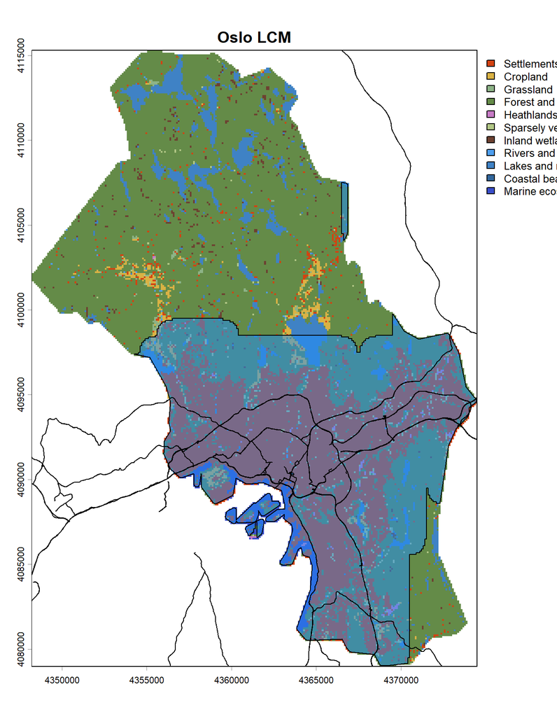

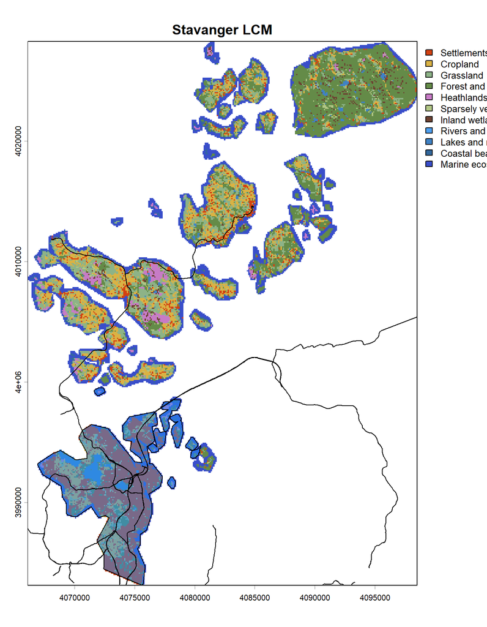

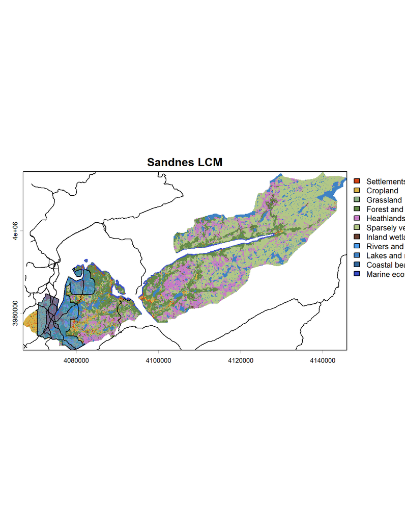

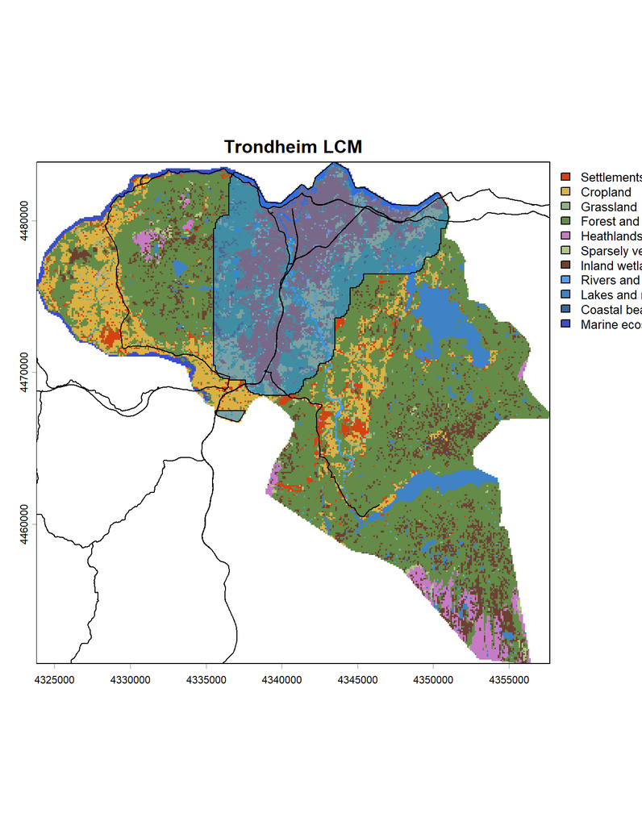

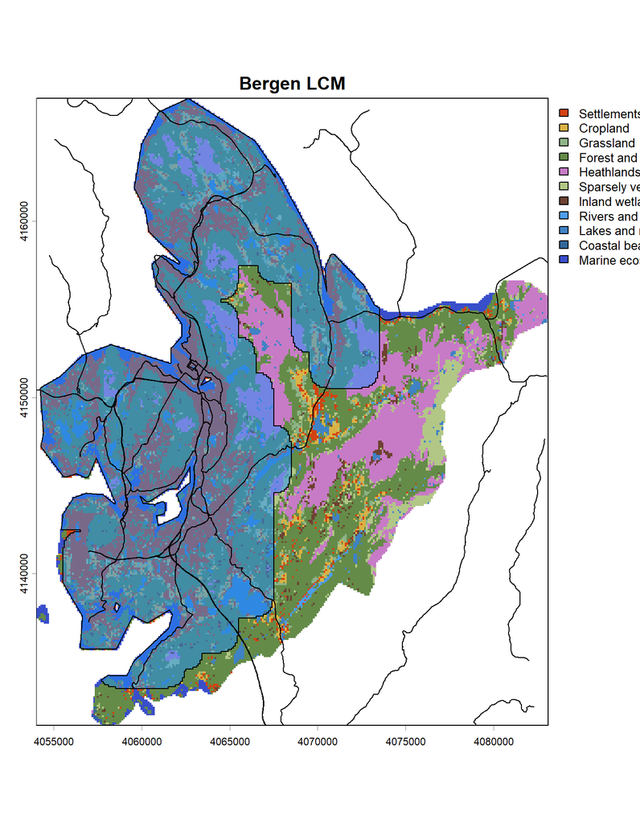

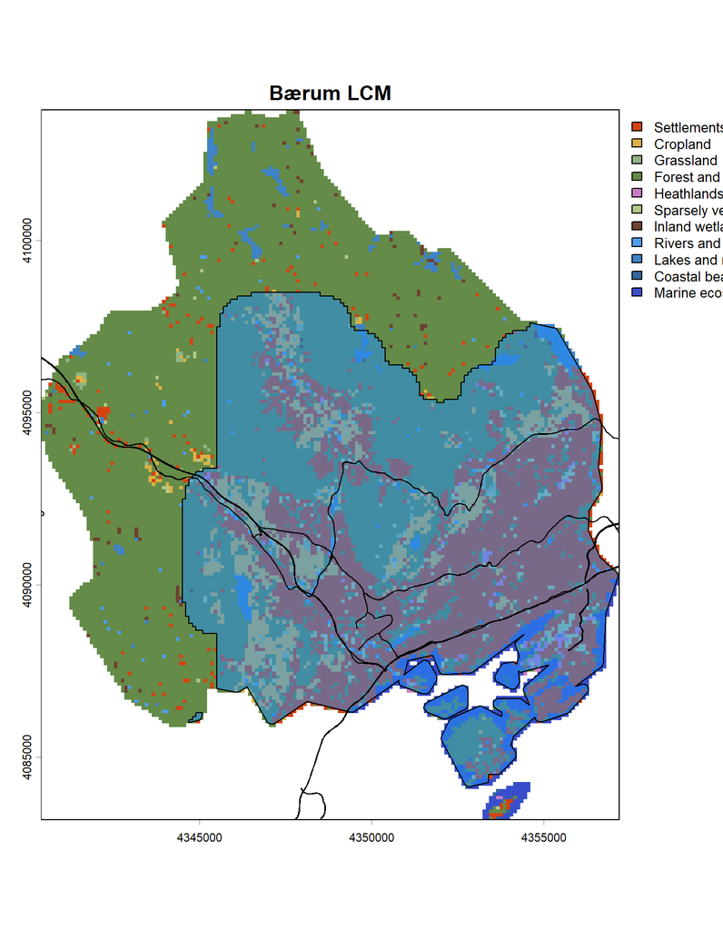

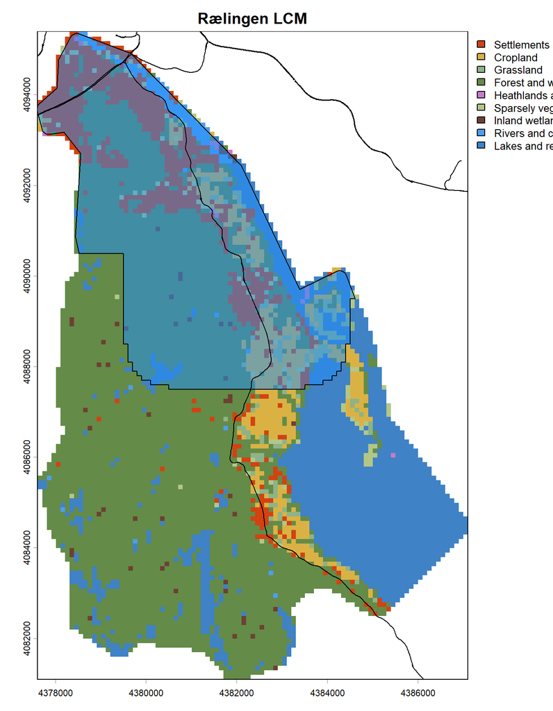

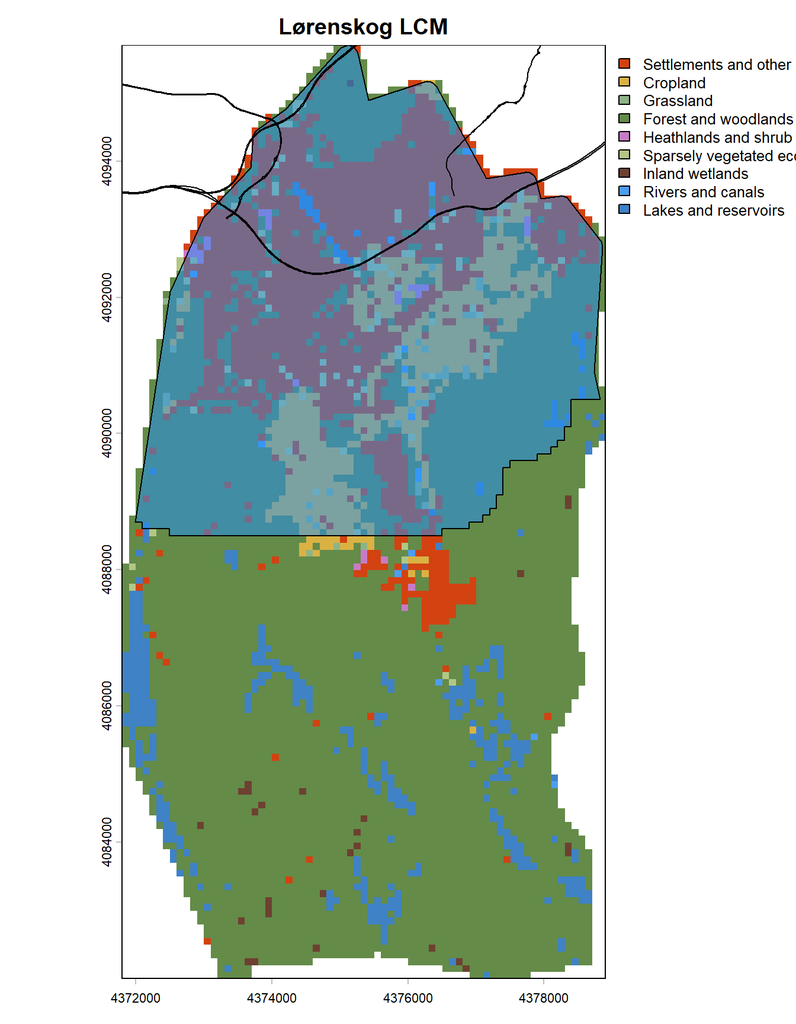

```r
# Make a plot of all cities
# import street data for better orientation
roads_list<-list()
for(i in 1:nrow(cityb_buf)){
  roads_list[[i]]<-terra::vect(file.path(here::here(),"ancillary_data",
                                         paste0("roads_",cityb_buf$LAU_ID[i],".shp")))
}
names(roads_list)<-cityb_buf$LAU_NAME
# Let's plot the data
for(i in 1:nrow(cityb_buf)){
  plot(mask(crop(lcm, cityb_buf[i,]),cityb_buf[i,]),main=paste(cityb_buf$LAU_NAME[i],"LCM"), legend=T)
  plot(cityb_buf_m[i,],col="dodgerblue",alpha=0.5, add=T)
  plot(roads_list[[i]],add=T)
}
```

Now next we need to identify which of these cities have experienced maximum daily temperatures of at least 25 degrees celsius in the reference year of 2024. For this purpose we use gridded COPERNICUS data on daily maximum temperatures. We aggregate this data to montly maps that show for each pixel the number of days on which temperatures exceeded 25 degrees. We then use this to filter for each month which urban areas have experienced any days with temperatures exceeding 25 degrees.

```r
gc()
# make a function
mask_heat_fun<-function(inputurbanshape,lcm,heatrast){
  # Step 1: rasterise the inputshape
  cityr<-terra::rasterize(inputurbanshape,lcm,field="LAU_ID")
  # Step 2: align heatraster with lcm and make binary
  heatrast<-resample(heatrast,lcm,method="near")
  heatrast[heatrast>0]<-1
  heatrast[heatrast==0]<-NA
  # Step 3: Mask the urban raster by what falls under the heat days category
  cityrm<-mask(cityr,heatrast)
  # Step 4: Identify city codes that fall into the category
  cities <- unique(na.omit(values(cityrm)))
  citycodes <- levels(cityr)[[1]]$LAU_ID[levels(cityr)[[1]]$ID %in% cities]
  # Step 5: filter city shape accordingly
  outputurbanshape <- inputurbanshape[inputurbanshape$LAU_ID %in% citycodes,]
  # Step 6: return result and tidy up
  rm(cityr,cityrm,cities,citycodes)
  return(outputurbanshape)
  gc()
}

# apply function
cityb_l<-list()
cityb_buf_l<-list()
cityb_buf_m_l<-list()
citytownb_l<-list()
mdr=c(6,7,8,9)
for(j in 1:length(mdr)){
  cityb_l[[j]]<-mask_heat_fun(inputurbanshape=cityb,
                    lcm=lcm,
                    heatrast=terra::rast(file.path(here::here(),"ancillary_data",paste0("heatdays_",j,".tif")))
                    )
  cityb_buf_l[[j]]<-mask_heat_fun(inputurbanshape=cityb_buf,
                    lcm=lcm,
                    heatrast=terra::rast(file.path(here::here(),"ancillary_data",paste0("heatdays_",j,".tif")))
                    )
  cityb_buf_m_l[[j]]<-mask_heat_fun(inputurbanshape=cityb_buf_m,
                    lcm=lcm,
                    heatrast=terra::rast(file.path(here::here(),"ancillary_data",paste0("heatdays_",j,".tif")))
                    )
  citytownb_l[[j]]<-mask_heat_fun(inputurbanshape=citytownb,
                    lcm=lcm,
                    heatrast=terra::rast(file.path(here::here(),"ancillary_data",paste0("heatdays_",j,".tif")))
                    )
  gc()
  }
# identify citytowns that never get included
cni<-citytownb$LAU_NAME[!citytownb$LAU_NAME %in% unique(c(citytownb_l[[1]]$LAU_NAME,citytownb_l[[2]]$LAU_NAME,citytownb_l[[3]]$LAU_NAME,citytownb_l[[4]]$LAU_NAME))]
```

Non-matching CRS doesn’t matter. Our analysis shows the following. Month June 2024 includes 8 cities, and 73 cities + towns that have experienced temperatures exceeding 25 degrees. Month July includes 8 cities and 71 cities + towns. Month August includes 5 cities and 46 cities + towns. Month September includes 8 cities and 65 cities + towns. So these are the areas we compute our cooling for, in each of the cases. Towns that do not get included in the computation in any month, because they did not experience days with temperatures exceeding 25 degrees, are: None.

Now, continuing on from here, we only analyse cities, because we do not have LST data covering towns as well. The extension of this quantification to towns is left for future versions of the quantification.

### 3.2.2 LST data

The Eurostat handbook suggests to use an inclusive approach. We therefore pick all available months for the LST data, which we read in next. Croping and reprojection is done outside of this script, because it is a computationally time-intensive process.

```r
gc()
# read LST raster file ---------------------------------------------------------
# Here we have data available for June, July, August, September, and we pick
# as described above.
lstr_6_no<-terra::rast(file.path(here::here(),"ancillary_data",
                                 "lstr_6_no.tif"))
lstr_7_no<-terra::rast(file.path(here::here(),"ancillary_data",
                                 "lstr_7_no.tif"))
lstr_8_no<-terra::rast(file.path(here::here(),"ancillary_data",
                                 "lstr_8_no.tif"))
lstr_9_no<-terra::rast(file.path(here::here(),"ancillary_data",
                                 "lstr_9_no.tif"))

# mask to city LAUs
lstr_6_no <- mask(crop(lstr_6_no,cityb_buf),cityb_buf)
lstr_7_no <- mask(crop(lstr_7_no,cityb_buf),cityb_buf)
lstr_8_no <- mask(crop(lstr_8_no,cityb_buf),cityb_buf)
lstr_9_no <- mask(crop(lstr_9_no,cityb_buf),cityb_buf)

## MM comment: The unit of the data is Kelvin. Vito has applied the scaling factor
# that is mentioned here:
# https://www.usgs.gov/landsat-missions/landsat-collection-2-surface-temperature
# You can trace the step in line 131 here
# https://code.europa.eu/inca/gis-plugins/gis-plugins/-/blob/main/src/inca/localclimate/preprocessing/preprocess_LST.js?ref_type=heads
# Before running regressions, VITO changes the unit to celsuis. See line 195 here:
# https://code.europa.eu/inca/gis-plugins/gis-plugins/-/blob/main/src/inca/localclimate/__init__.py?ref_type=heads
# so we do that here too.
lstr_6_no <- lstr_6_no - 273.15
lstr_7_no <- lstr_7_no - 273.15
lstr_8_no <- lstr_8_no - 273.15
lstr_9_no <- lstr_9_no - 273.15

# Move LST data all into one stack
lstr_stack <- c(lstr_6_no,lstr_7_no,lstr_8_no,lstr_9_no)
rm(lstr_6_no,lstr_7_no,lstr_8_no,lstr_9_no)
```

Then plot the LST data, to show that it has gaps. We use the land cover map as background. First for June:

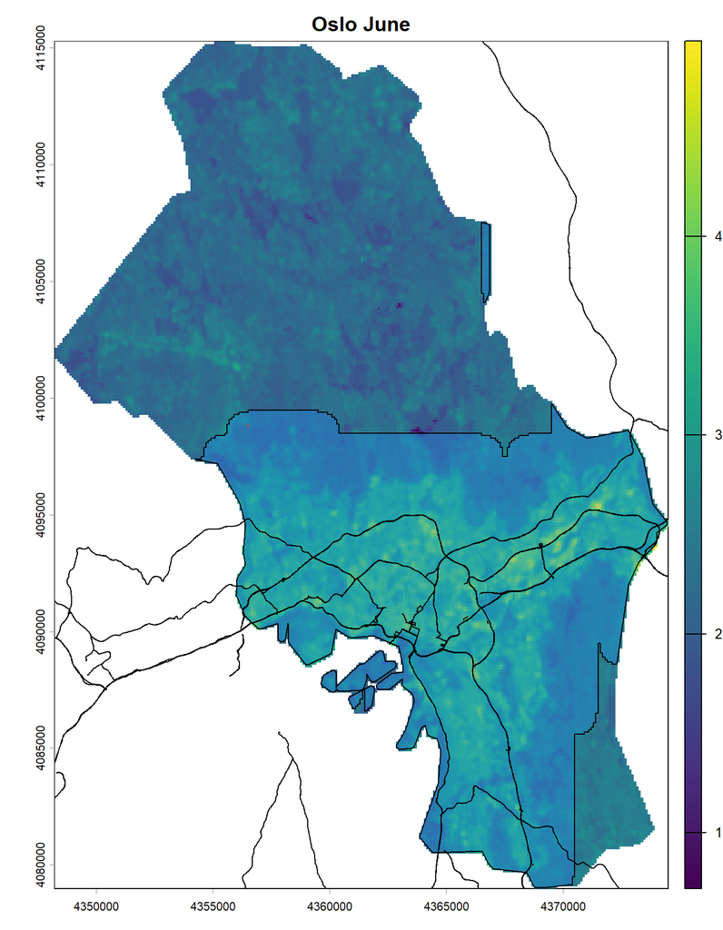

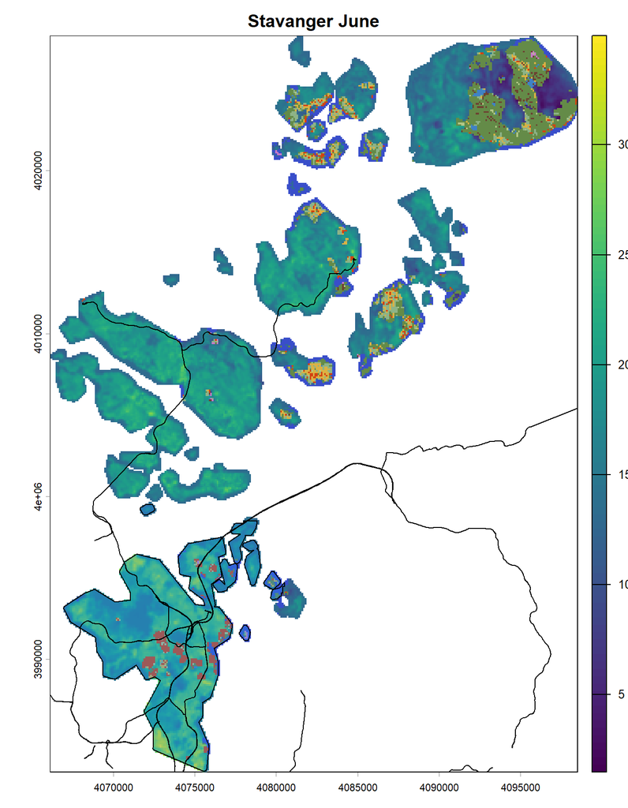

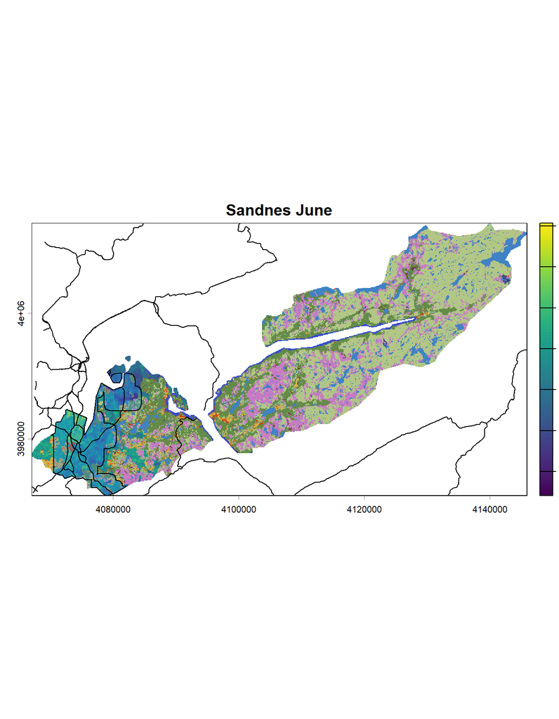

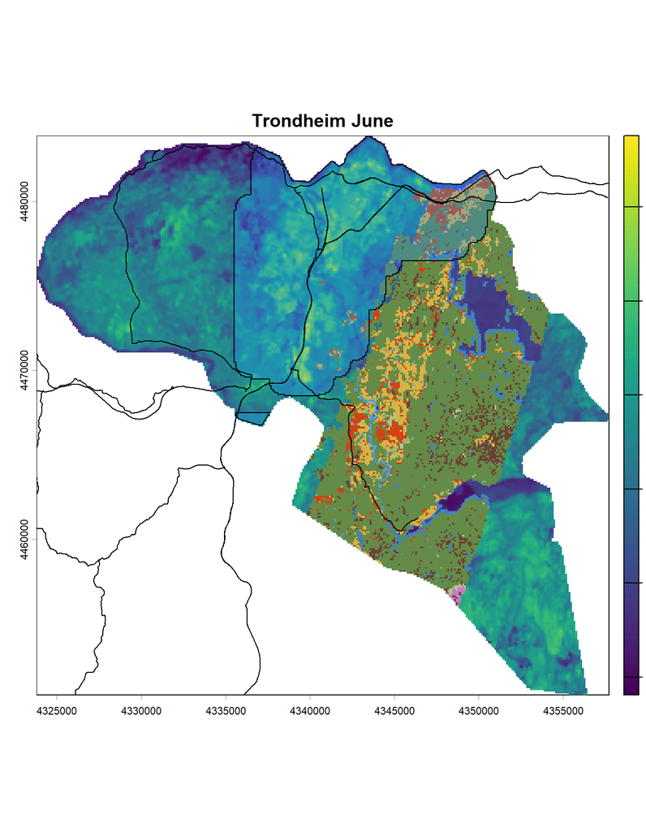

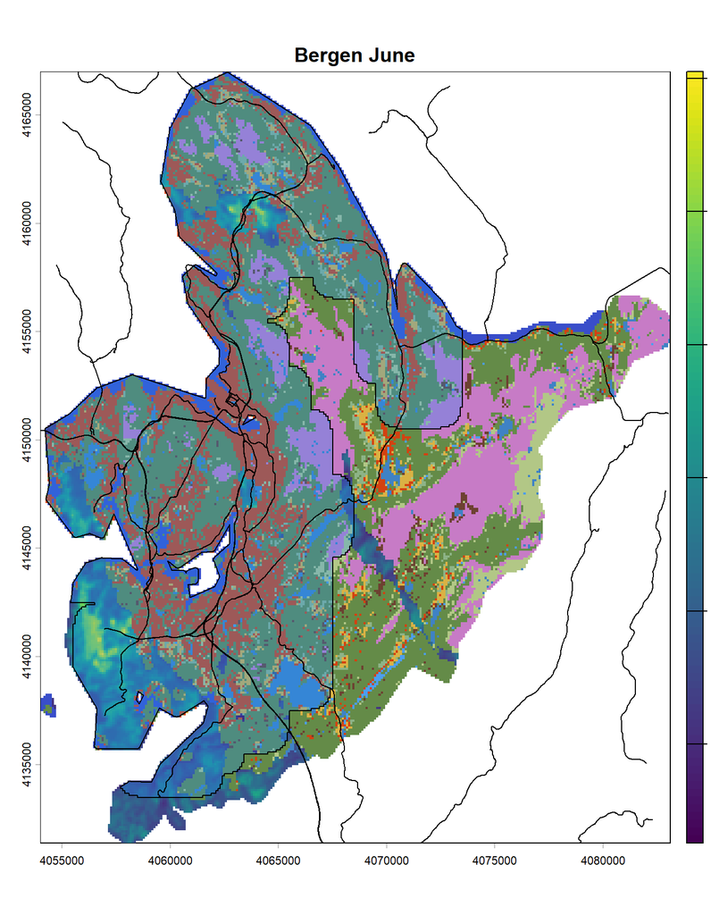

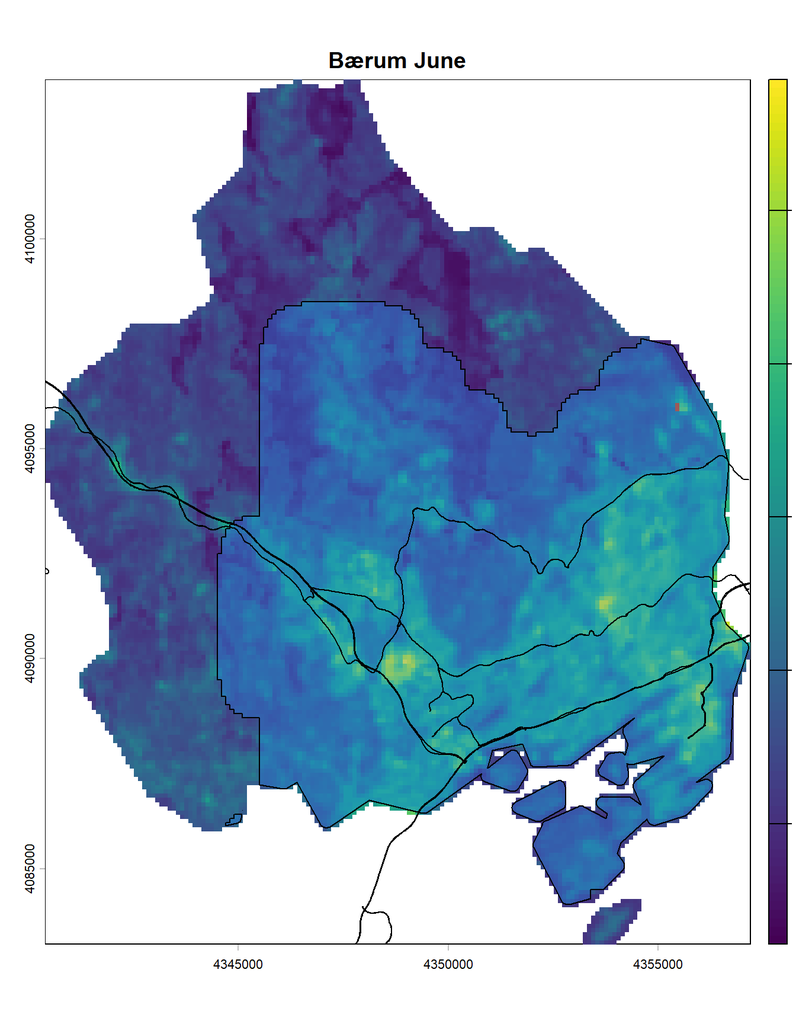

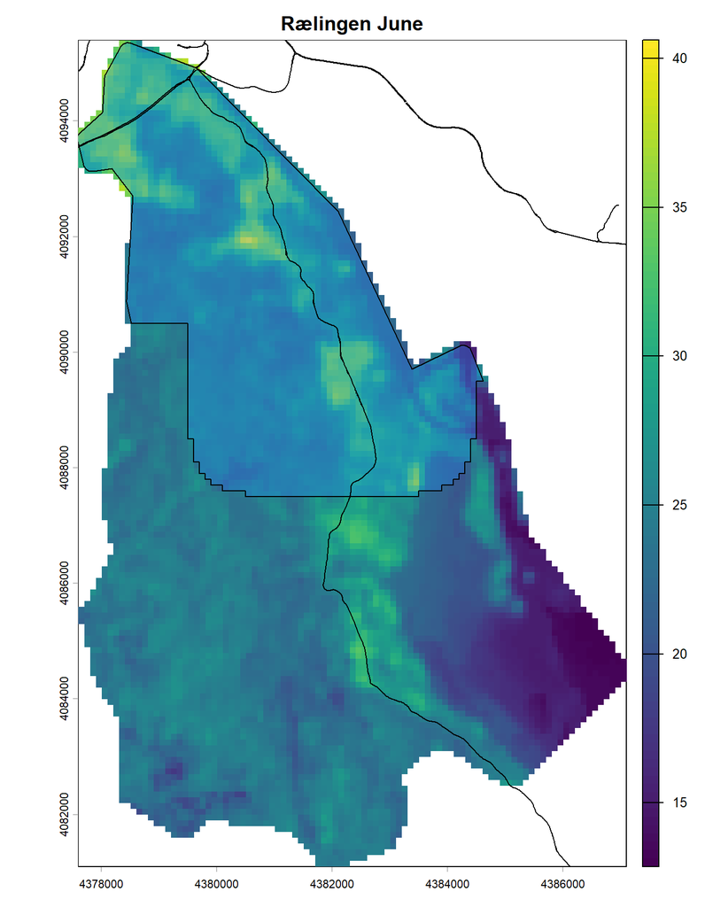

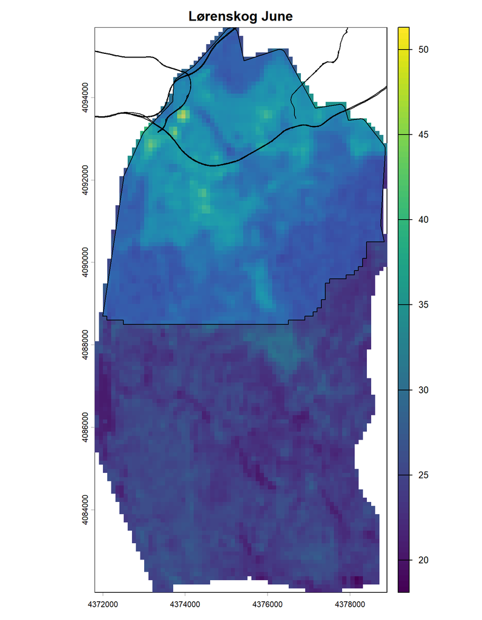

```r
gc()
# Let's plot the data
for(i in 1:nrow(cityb_buf)){
plot(mask(crop(lcm, cityb_buf[i,]),cityb_buf[i,]),main=paste(cityb_buf$LAU_NAME[i],"June"), legend=F)
plot(mask(crop(lstr_stack[[1]], cityb_buf[i,]),cityb_buf[i,]),add=T)
plot(cityb_buf_m[i,],alpha=0.3,col="dodgerblue",add=T)
plot(roads_list[[i]],add=T)
}
```

You see the largets data gaps for Sandnes and Bergen. Also some gaps for Trondheim and Stavanger. Then look at the maps for July:

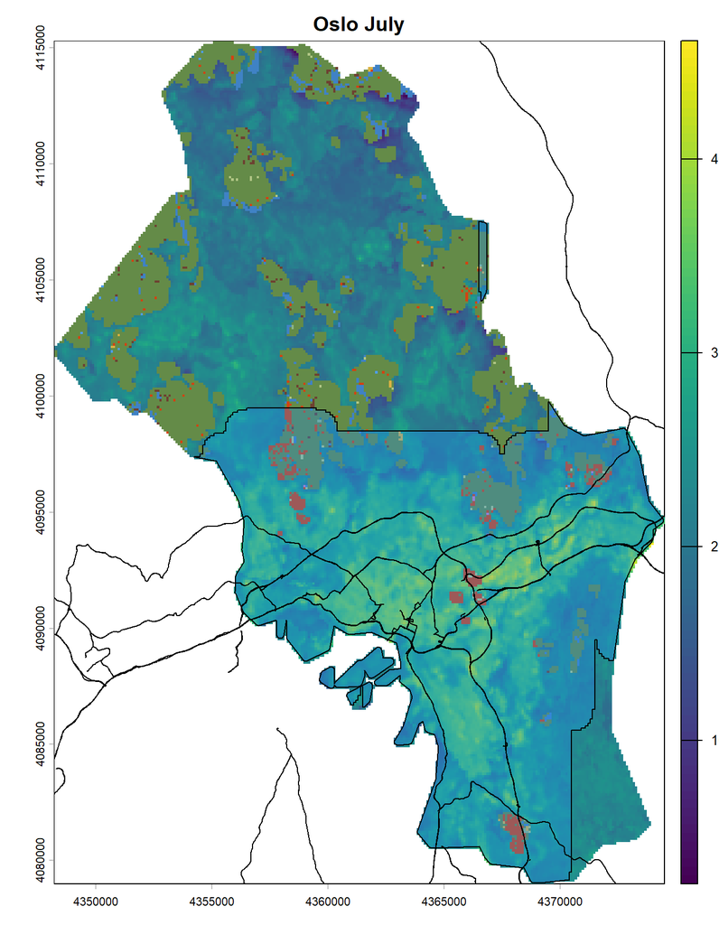

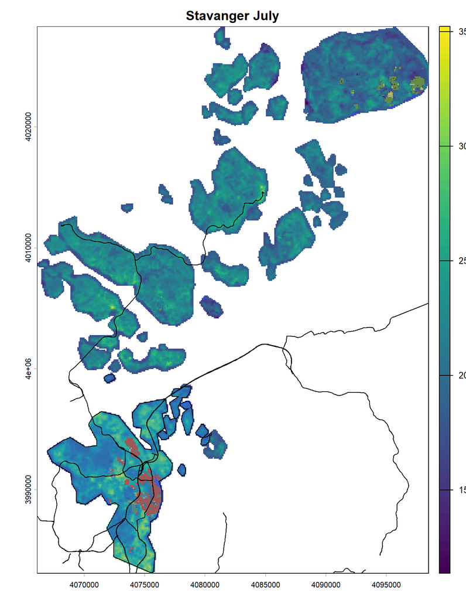

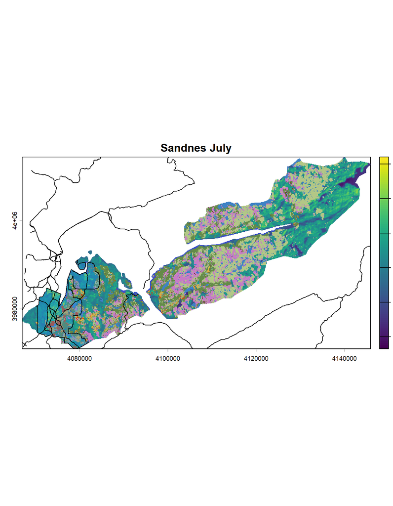

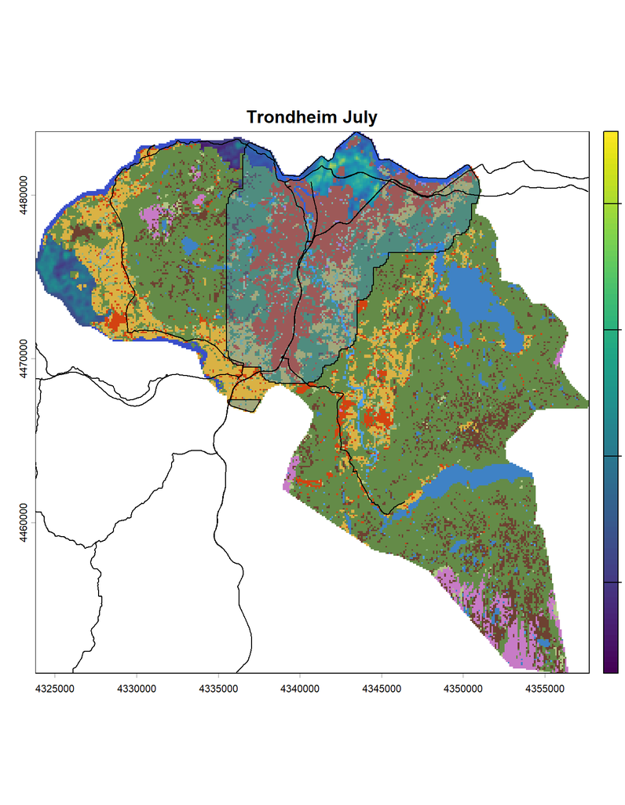

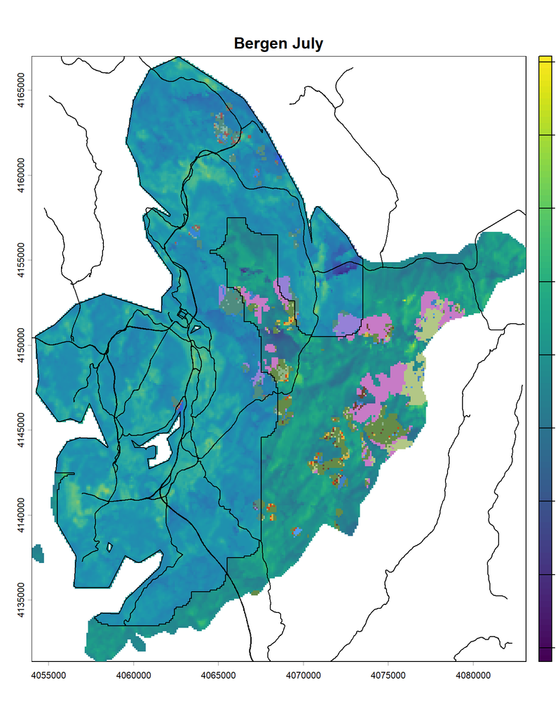

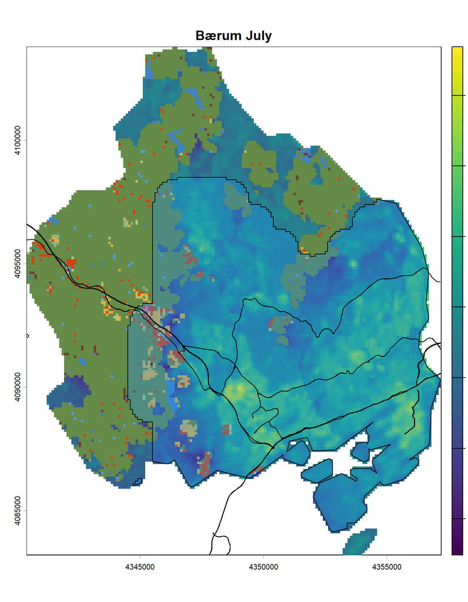

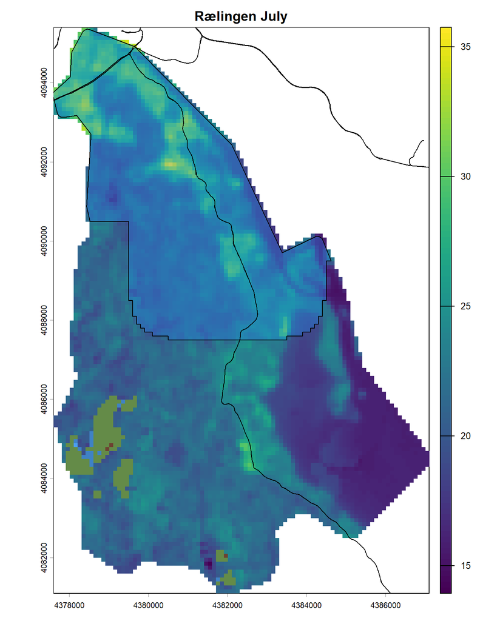

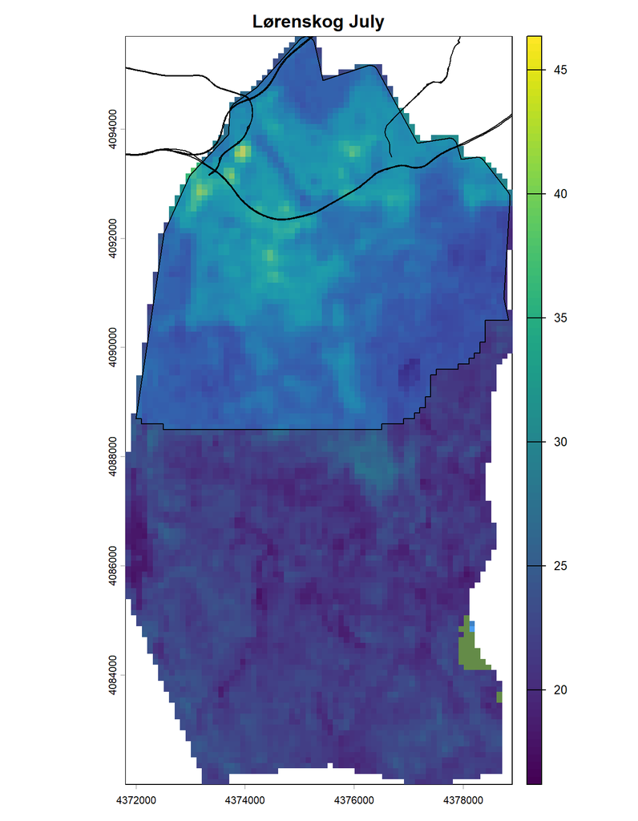

```r
gc()
# Let's plot the data
for(i in 1:nrow(cityb_buf)){
plot(mask(crop(lcm, cityb_buf[i,]),cityb_buf[i,]),main=paste(cityb_buf$LAU_NAME[i],"July"), legend=F)
plot(mask(crop(lstr_stack[[2]], cityb_buf[i,]),cityb_buf[i,]),add=T)
plot(cityb_buf_m[i,],alpha=0.3,col="dodgerblue",add=T)
plot(roads_list[[i]],add=T)
}
```

So for month July the largest gaps prevail in the LST data for Sandnes, Trondheim, and Bærum. Also substantial gaps for Oslo and Bergen, and some for Stavanger, Rælingen, and Lørenskog. The gaps do not look much different in the data for the other available months, so I omit plotting those here. I was wondering whether they could occur due to clouds, blanking out parts of the original satellite picture? On the other hand, I notice that some of the gaps look quite similar across months, which makes the cloud hypothesis less likely. In any case, what we could do in a next version is to compute median or mean values across months first, so we get an LST map with the best possible coverage. Given that INCA only reads in one single LST file at a time, I currently stick to the seperate month-wise calculations, to allow comparison of resuts to INCA outputs.

### 3.2.3 TC and EVAP data

Then we read in the other raster files needed. Tree cover density and then evaporation. For evaporation we have the choice between different datasets. One covering July to August, one covering June to August, and a third covering June to September. There is no guidance in the Eurostat handbook on which data to choose. To match the LST data selection, we choose to use June to September.

```r
gc()
# rough crop
norcrop <- ext(
  3.5e6, 5.5e6, # xmin, xmax
  3.5e6, 5.5e6 # ymin, ymax
)

# read EVAP raster file --------------------------------------------------------
evapr<-terra::rast(file.path(d_fp,"version_2026_7",
                           "inca_input_local_climate_regulation",
                           "Vegetation_Evapotranspiration","2024",
                           "interc_transp_2024_Jun-Jul-Aug-Sept.tif"))
# I have found one funny thing here. The metadata in this raster file includes a
# scale factor of 0.01. R terra automatically applies this to the values of the
# file, so it contains realistic numbers. But the python code in INCA does not
# apply the scale factor. Therefore, numbers in INCA for evapotranspiration are
# 100 times larger than here. For now, I manually change this here, so we have
# results as close as possible.

# rough crop
evapr_no <- crop(evapr,norcrop)
# reproject
evapr_no <- terra::project(evapr_no,crs(lcm),res=res(evapr_no),method="bilinear")
# mask to city lau
evapr_no <- mask(crop(evapr_no,cityb_buf),cityb_buf)
# evapr_no <- 100*evapr_no # this step to immitate what INCA does (but it actually
# is not correct)
# When plotting the resulting map we see that it is a bit patchy, too. Possibly
# revisit later.


# read TCD raster file ---------------------------------------------------------
tcdr<-terra::rast(file.path(d_fp,"version_2026_7",
                           "inca_input_local_climate_regulation",
                           "Tree_Cover_Density","2023",
                           "TCD_100m_2023_compressed.tif"))
# rough crop
tcdr_no <- crop(tcdr,norcrop)
# reproject
tcdr_no <- terra::project(tcdr_no,evapr_no)
# mask to city lau
tcdr_no <- mask(crop(tcdr_no,cityb_buf),cityb_buf)
# MM I have checked the resulting data and it looks fine. No gaps.

# reproject lst raster data ----------------------------------------------------
lstr_stack<-terra::project(lstr_stack,evapr_no)

# tidy up
rm(tcdr,evapr)
```

Before we continue on with estimating our models, we first create a spatial mask for each month that represents the valid pixels we can base the model on.

```r
mask_6_no<-terra::ifel(!is.na(evapr_no) & !is.na(tcdr_no) & !is.na(lstr_stack[[1]]),1,NA)
mask_7_no<-terra::ifel(!is.na(evapr_no) & !is.na(tcdr_no) & !is.na(lstr_stack[[2]]),1,NA)
mask_8_no<-terra::ifel(!is.na(evapr_no) & !is.na(tcdr_no) & !is.na(lstr_stack[[3]]),1,NA)
mask_9_no<-terra::ifel(!is.na(evapr_no) & !is.na(tcdr_no) & !is.na(lstr_stack[[4]]),1,NA)

mask_stack<-c(mask_6_no,mask_7_no,mask_8_no,mask_9_no)
# then we need lcm, make sure it is aligned with the rest of the raster data
lcm2 <- resample(lcm,mask_stack,method='near')
#clean up
rm(mask_6_no,mask_7_no,mask_8_no,mask_9_no)
gc()
```

## 3.3 Run regressions

We loop across cities and across available months here. In each city and month we run a regression where grid cells are units of observation. Predicting LST with TCD and EVAP. We store the resulting coefficients for each city and month.

```r
gc()
# months to consider
mdr<-c(6,7,8,9)

# our dataframe for results
reg1df<-as.data.frame(matrix(nrow=1,ncol=14))
colnames(reg1df)<-c("month","city","pixels_in_shp","p_pixels_used","p_pixels_rm",
                    "p_pixels_rm_due_na_lcm","p_pixels_rm_due_na_data","avg_lst",
                    "avg_tcd","avg_evap","est_intercept","est_tcd","est_evap",
                    "R2")
# function
first_regression_function<-function(cityshp,lst_rfile,tcd_rfile,evap_rfile){
  # Step 1: Crop the data to the right shape, stack it, and turn into df
  estack <- c(
    crop(lst_rfile, cityshp, mask = TRUE),
    crop(tcd_rfile, cityshp, mask = TRUE),
    crop(evap_rfile, cityshp, mask = TRUE))
  names(estack)<-c("lst","tcd","evap")
  edf<-as.data.frame(estack)
  clean_edf <- edf %>% drop_na()
  rm(estack)
  # Step 2: Run regression
  elm <- lm(lst ~ tcd + evap, data = edf)
  # Step 3: Save relevant info
  rv<-vector()
  # total pixel number in shape
  rv[1] <- mask(crop(init(lst_rfile, 1), cityshp), cityshp) %>% ncell()
  # proportion of pixels used
  rv[2] <- nobs(elm) / rv[1]
  # proportion of pixels removed
  rv[3] <- 1 - rv[2]
  # proportion of pixels removed because outside of lcm data
  rv[4] <- 1 - (nrow(edf) / rv[1])
  # proportion of pixels removed because of data gaps (lst,tcd,evap)
  rv[5] <- (nrow(edf) - nobs(elm)) / rv[1]
  # average land surface temp
  rv[6] <- mean(clean_edf$lst)
  # average tree cover density
  rv[7] <- mean(clean_edf$tcd)
  # average evapotranspiration
  rv[8] <- mean(clean_edf$evap)
  # estimated intercept
  rv[9] <- elm$coefficients[1]
  # estimated coefficient on tre cover density
  rv[10] <- elm$coefficients[2]
  # estimated coefficient on evaporation
  rv[11] <- elm$coefficients[3]
  # model fit
  rv[12] <- summary(elm)$r.squared
  # clean up and return result
  rm(edf,clean_edf,elm)
  return(rv)
}

## then loop across months and cities (eurostat version)
rl<-list()
for(j in 1:length(mdr)){
  rl[[j]]<-reg1df
  for(i in 1:nrow(cityb_buf)){
    rl[[j]][i,1]<-mdr[j]
    rl[[j]][i,2]<-as.data.frame(cityb_buf[i,])$LAU_NAME
    rl[[j]][i,3:14]<-first_regression_function(cityshp = cityb_buf[i,],
                                lst_rfile = lstr_stack[[j]],
                                tcd_rfile = tcdr_no,
                                evap_rfile = evapr_no)
  }
}
firstdf<-do.call("rbind",rl)
# add city codes
firstdf <- firstdf %>%
  mutate(city_code = cityb_buf$LAU_ID[match(city,cityb_buf$LAU_NAME)]) %>%
  relocate(city_code,.after=city)
#clean up
rm(rl)

## then loop across months and cities (strict urban version)
rl<-list()
for(j in 1:length(mdr)){
  rl[[j]]<-reg1df
  for(i in 1:nrow(cityb_buf_m)){
    rl[[j]][i,1]<-mdr[j]
    rl[[j]][i,2]<-as.data.frame(cityb_buf_m[i,])$LAU_NAME
    rl[[j]][i,3:14]<-first_regression_function(cityshp = cityb_buf_m[i,],
                                lst_rfile = lstr_stack[[j]],
                                tcd_rfile = tcdr_no,
                                evap_rfile = evapr_no)
  }
}
firstdf_n<-do.call("rbind",rl)
# add city codes
firstdf_n <- firstdf_n %>%
  mutate(city_code = cityb_buf_m$LAU_ID[match(city,cityb_buf_m$LAU_NAME)]) %>%
  relocate(city_code,.after=city)
#clean up
rm(reg1df,rl)
```

Print the table, with rounded values (and some less interesting rows and columns removed). Here the Eurostat version. We remove cities that have not experienced heat in the respective month.

```r
# print result table
kable(firstdf %>%
        filter((month==6 & city_code %in% cityb_l[[1]]$LAU_ID) | (month == 7 & city_code %in% cityb_l[[2]]$LAU_ID)) %>%
        select(-c(p_pixels_rm,p_pixels_rm_due_na_lcm,p_pixels_rm_due_na_data)) %>%
        mutate(across(where(is.numeric), ~ round(.x, 2))))
```

| month | city | city_code | pixels_in_shp | p_pixels_used | avg_lst | avg_tcd | avg_evap | est_intercept | est_tcd | est_evap | R2 |
| --- | --- | --- | --- | --- | --- | --- | --- | --- | --- | --- | --- |
| 6 | Oslo | 301 | 42175 | 0.50 | 25.86 | 53.22 | 0.89 | 33.02 | -0.10 | -2.00 | 0.57 |
| 6 | Stavanger | 1103 | 64800 | 0.13 | 18.71 | 21.04 | 1.07 | 23.61 | -0.09 | -2.85 | 0.43 |
| 6 | Sandnes | 1108 | 152014 | 0.04 | 18.04 | 16.99 | 0.90 | 21.37 | -0.10 | -1.77 | 0.33 |
| 6 | Trondheim | 5001 | 49946 | 0.30 | 22.68 | 33.99 | 0.89 | 26.66 | -0.04 | -2.99 | 0.21 |
| 6 | Bergen | 4601 | 45978 | 0.05 | 18.24 | 35.38 | 0.94 | 25.42 | -0.09 | -4.27 | 0.46 |
| 6 | Bærum | 3024 | 15456 | 0.59 | 25.21 | 54.88 | 1.15 | 32.47 | -0.10 | -1.44 | 0.61 |
| 6 | Rælingen | 3027 | 5985 | 0.52 | 25.34 | 56.44 | 0.95 | 25.57 | -0.05 | 2.92 | 0.23 |
| 6 | Lørenskog | 3029 | 4416 | 0.79 | 26.97 | 56.08 | 1.06 | 35.60 | -0.08 | -3.65 | 0.65 |
| 7 | Oslo | 301 | 42175 | 0.39 | 24.90 | 48.31 | 0.84 | 31.24 | -0.10 | -1.71 | 0.50 |
| 7 | Stavanger | 1103 | 64800 | 0.16 | 22.04 | 23.63 | 1.11 | 25.08 | -0.04 | -1.79 | 0.34 |
| 7 | Sandnes | 1108 | 152014 | 0.12 | 22.32 | 10.69 | 0.50 | 22.96 | -0.04 | -0.49 | 0.08 |
| 7 | Trondheim | 5001 | 49946 | 0.02 | 19.66 | 28.09 | 0.86 | 22.70 | -0.05 | -1.93 | 0.51 |
| 7 | Bergen | 4601 | 45978 | 0.39 | 20.91 | 36.70 | 0.99 | 25.04 | -0.05 | -2.39 | 0.28 |
| 7 | Bærum | 3024 | 15456 | 0.35 | 25.33 | 41.33 | 1.09 | 32.13 | -0.07 | -3.40 | 0.47 |
| 7 | Rælingen | 3027 | 5985 | 0.50 | 22.34 | 55.75 | 0.95 | 23.10 | -0.04 | 1.72 | 0.21 |
| 7 | Lørenskog | 3029 | 4416 | 0.79 | 24.09 | 55.95 | 1.06 | 32.46 | -0.08 | -3.62 | 0.65 |

And here the version with stricter urban definition.

```r
# print result table
kable(firstdf_n %>%
        filter((month==6 & city_code %in% cityb_l[[1]]$LAU_ID) | (month == 7 & city_code %in% cityb_l[[2]]$LAU_ID)) %>%
        select(-c(p_pixels_rm,p_pixels_rm_due_na_lcm,p_pixels_rm_due_na_data)) %>%
        mutate(across(where(is.numeric), ~ round(.x, 2))))
```

| month | city | city_code | pixels_in_shp | p_pixels_used | avg_lst | avg_tcd | avg_evap | est_intercept | est_tcd | est_evap | R2 |
| --- | --- | --- | --- | --- | --- | --- | --- | --- | --- | --- | --- |
| 6 | Oslo | 301 | 25650 | 0.39 | 29.71 | 35.79 | 0.70 | 34.99 | -0.10 | -2.25 | 0.68 |
| 6 | Stavanger | 1103 | 9810 | 0.27 | 22.32 | 9.51 | 0.47 | 24.73 | -0.08 | -3.55 | 0.35 |
| 6 | Sandnes | 1108 | 12864 | 0.31 | 18.41 | 15.50 | 0.86 | 22.69 | -0.11 | -3.03 | 0.37 |
| 6 | Trondheim | 5001 | 11856 | 0.44 | 24.37 | 28.44 | 0.76 | 28.75 | -0.08 | -2.96 | 0.52 |
| 6 | Bergen | 4601 | 28767 | 0.06 | 19.04 | 33.74 | 0.90 | 26.48 | -0.10 | -4.62 | 0.51 |
| 6 | Bærum | 3024 | 8160 | 0.67 | 27.21 | 40.51 | 1.12 | 33.39 | -0.09 | -2.16 | 0.57 |
| 6 | Rælingen | 3027 | 2491 | 0.53 | 26.85 | 45.09 | 0.90 | 28.20 | -0.07 | 1.91 | 0.35 |
| 6 | Lørenskog | 3029 | 2160 | 0.74 | 29.76 | 35.91 | 0.98 | 37.79 | -0.09 | -4.98 | 0.75 |
| 7 | Oslo | 301 | 25650 | 0.35 | 28.31 | 32.41 | 0.66 | 33.06 | -0.10 | -2.37 | 0.59 |
| 7 | Stavanger | 1103 | 9810 | 0.26 | 24.18 | 9.33 | 0.49 | 26.26 | -0.05 | -3.32 | 0.25 |
| 7 | Sandnes | 1108 | 12864 | 0.24 | 23.36 | 13.42 | 0.87 | 27.56 | -0.05 | -4.10 | 0.53 |
| 7 | Trondheim | 5001 | 11856 | 0.04 | 21.29 | 15.12 | 0.37 | 23.20 | -0.09 | -1.45 | 0.51 |
| 7 | Bergen | 4601 | 28767 | 0.43 | 21.32 | 37.23 | 0.94 | 26.25 | -0.06 | -2.71 | 0.38 |
| 7 | Bærum | 3024 | 8160 | 0.57 | 26.08 | 35.09 | 1.07 | 32.21 | -0.07 | -3.51 | 0.42 |
| 7 | Rælingen | 3027 | 2491 | 0.53 | 23.34 | 45.09 | 0.90 | 25.54 | -0.06 | 0.53 | 0.34 |
| 7 | Lørenskog | 3029 | 2160 | 0.74 | 26.73 | 35.91 | 0.98 | 34.32 | -0.08 | -4.68 | 0.71 |

# 4. Estimate a model of air temp

## 4.1 Overview

In this second step we use weather station data to estimate a linear model of maximum air temperature predicted by local surface temperature and latitude. Here is the unit of observation is weather stations. We save the estimated coefficients.

## 4.2 Import data

Read in a single dataframe containing weather station data. This is the training data from the US.

```r
gc()
# read in weather station data
wstd<-read.csv(file.path(d_fp,"version_2026_7",
                           "inca_input_local_climate_regulation",
                           "Weather_station_data",
                           "StationNeighborhood2016.csv"))
```

## 4.3 Run regression

A single regression to estimate a linear model. Predicting maximum air temperature with local surface temperature and latitude. The model we estimate is:
$$T^{air} = \beta_{2} LST +
\gamma_{2}LAT$$

```r
gc()
# So here we now estimate the model and store the coefficients and adjusted r squared
wlm <- lm(TempMax ~ st + Ycoor, data = wstd)
alpha2h <- wlm$coefficients['(Intercept)']
beta2h <- wlm$coefficients['st']
gamma2h <- wlm$coefficients['Ycoor']
wlm_adjr2<-summary(wlm)$adj.r.squared
# tidy up
rm(wstd)
```

Here are model outputs:

```r
summary(wlm)
```

```
##
## Call:
## lm(formula = TempMax ~ st + Ycoor, data = wstd)
##
## Residuals:
##     Min      1Q  Median      3Q     Max
## -14.325  -1.181   1.004   2.027  12.798
##
## Coefficients:
##              Estimate Std. Error t value Pr(>|t|)
## (Intercept) 40.633197   0.440522   92.24   <2e-16 ***
## st           0.256994   0.006482   39.65   <2e-16 ***
## Ycoor       -0.524943   0.008085  -64.93   <2e-16 ***
## ---
## Signif. codes:  0 '***' 0.001 '**' 0.01 '*' 0.05 '.' 0.1 ' ' 1
##
## Residual standard error: 3.251 on 6507 degrees of freedom
## Multiple R-squared:  0.5214, Adjusted R-squared:  0.5213
## F-statistic:  3545 on 2 and 6507 DF,  p-value: < 2.2e-16
```

```r
rm(wlm)
```

# 5. Simulate air temp for cities

## 5.1 Overview

Here we now apply the estimated coefficients from the previous two steps to generate simulated data. We do this for each city.

We first compute for each grid cell $i$ and month $j$ the expected air temperature $\widehat{T}^{air_{obsLSTgreen}}_{j,i}$ given observed conditions.

$$\widehat{T}^{air_{obsLSTgreen}}_{j,i} =
\widehat{\alpha}_{2} + \widehat{\beta}_{2}LST_{j,i} +
\widehat{\gamma}_{2} LAT{j,i}$$
.

Then we compute for each grid cell $i$ and month $j$ the expected air temperature in a no-vegetation scenario, i.e. where $\widehat{LST}^{zero}_{j,i} = \widehat{\alpha}_{1,j}$ because $TCD = EVAP = 0$ in this case. So

$$\widehat{T}^{air_{simLSTgray}}_{j,i} =
\widehat{\alpha}_{2} + \widehat{\beta}_{2} \widehat{LST}^{zero}_{j,i} +
\widehat{\gamma}_{2} LAT_{j,i}$$
.

It is important to note that $\widehat{LST}^{zero}_{j,i}$ is constant for each grid cell in a city-month, because we only get one $\widehat{\alpha}_{1,j}$ for each city-month. This again implies that $\widehat{T}^{air_{simLSTgray}}_{j,i}$ actually only varies across the north-south dimension due to varying latitude. The cooling effect is then retrieved for each grid cell $i$ in city $j$ as

$$\widehat{cooling_{j,i}} =
\widehat{T}^{air_{simLSTgray}}_{j,i} -
\widehat{T}^{air_{obsLSTgreen}}_{j,i}$$
.

As the formulation shows, cooling is a function of the estimated intercept of the first regression, the estimated coefficient on local surface temperature from the second regression, and the observed local surface temperature data.

## 5.2 Compute cooling (eurostat version)

Make a loop where we compute the cooling for each city in each month. Based on the method, it is possible to get positive and negative cooling values for pixels. The guidance says nothing about that.

```r
gc()

# make a dataframe from firstdf
cooldf<-firstdf %>% select(month,city,city_code,pixels_in_shp,p_pixels_used)
cooldf['T_air_sim']<-NA
cooldf['T_air_zero_sim']<-NA
cooldf['average_cooling']<-NA
cooldf['median_cooling']<-NA

# Project raster to geographic coordinates
tmp_ll <- project(lstr_stack[[1]], "EPSG:4326")
# Create latitude raster
lat_ll <- init(tmp_ll, "y")
# Back to the original grid
lat_r <- project(lat_ll, lstr_stack[[1]])
rm(tmp_ll,lat_ll)

# loop across months and cities
for(j in 1:length(mdr)){
  for(i in 1:nrow(cityb_buf)){
    # Step 1: Move spatial data into dataframe
    estack <- c(
      crop(lstr_stack[[j]], cityb_buf[i,], mask = TRUE),
      crop(tcdr_no, cityb_buf[i,], mask = TRUE),
      crop(evapr_no, cityb_buf[i,], mask = TRUE),
      crop(lat_r, cityb_buf[i,], mask = TRUE))
    names(estack)<-c("lst","tcd","evap","lat")
    cmdf<-as.data.frame(estack) %>% drop_na()
    # Step 2: Fill
    cmdf['alpha1h'] <- firstdf %>% filter(month==mdr[j] & city==cityb_buf$LAU_NAME[i]) %>% select(est_intercept)
    cmdf['beta1h'] <- firstdf %>% filter(month==mdr[j] & city==cityb_buf$LAU_NAME[i]) %>% select(est_tcd)
    cmdf['gamma1h'] <- firstdf %>% filter(month==mdr[j] & city==cityb_buf$LAU_NAME[i]) %>% select(est_evap)
    #cmdf['lst_h'] <-  cmdf$alpha1h + (cmdf$tcd*cmdf$beta1h) + (cmdf$evap*cmdf$gamma1h)
    cmdf['t_air_h'] <- alpha2h + (cmdf$lst*beta2h) + (cmdf$lat*gamma2h)
    cmdf['t_air_zero_h'] <- alpha2h + (cmdf$alpha1h*beta2h) + (cmdf$lat*gamma2h)
    cmdf['cool'] <- cmdf$t_air_zero_h - cmdf$t_air_h
    # Step 3: Move into cooldf
    cooldf$T_air_sim[cooldf$month==mdr[j] & cooldf$city==cityb_buf$LAU_NAME[i]] <- mean(cmdf$t_air_h)
    cooldf$T_air_zero_sim[cooldf$month==mdr[j] & cooldf$city==cityb_buf$LAU_NAME[i]] <- mean(cmdf$t_air_zero_h)
    cooldf$average_cooling[cooldf$month==mdr[j] & cooldf$city==cityb_buf$LAU_NAME[i]] <- mean(cmdf$cool)
    cooldf$median_cooling[cooldf$month==mdr[j] & cooldf$city==cityb_buf$LAU_NAME[i]] <- median(cmdf$cool)
    # Step 4: Clean up
    rm(estack,cmdf)
  }
}
# save
cooldf_e<-cooldf
rm(cooldf)
```

Here is the resulting table (I only show June and July here, to make results easier to digest). Again we remove whatever cities have not experienced hot days in the respective month

```r
# print result table
kable(cooldf_e %>%
        filter((month==6 & city_code %in% cityb_l[[1]]$LAU_ID) | (month == 7 & city_code %in% cityb_l[[2]]$LAU_ID)) %>%
        mutate(across(where(is.numeric), ~ round(.x, 2))))
```

| month | city | city_code | pixels_in_shp | p_pixels_used | T_air_sim | T_air_zero_sim | average_cooling | median_cooling |
| --- | --- | --- | --- | --- | --- | --- | --- | --- |
| 6 | Oslo | 301 | 42175 | 0.50 | 15.79 | 17.63 | 1.84 | 2.35 |
| 6 | Stavanger | 1103 | 64800 | 0.13 | 14.42 | 15.68 | 1.26 | 1.17 |
| 6 | Sandnes | 1108 | 152014 | 0.04 | 14.37 | 15.23 | 0.86 | 0.78 |
| 6 | Trondheim | 5001 | 49946 | 0.30 | 13.21 | 14.23 | 1.02 | 0.98 |
| 6 | Bergen | 4601 | 45978 | 0.05 | 13.66 | 15.51 | 1.84 | 2.15 |
| 6 | Bærum | 3024 | 15456 | 0.59 | 15.65 | 17.51 | 1.87 | 2.22 |
| 6 | Rælingen | 3027 | 5985 | 0.52 | 15.71 | 15.77 | 0.06 | 0.24 |
| 6 | Lørenskog | 3029 | 4416 | 0.79 | 16.12 | 18.34 | 2.22 | 2.64 |
| 7 | Oslo | 301 | 42175 | 0.39 | 15.55 | 17.18 | 1.63 | 2.01 |
| 7 | Stavanger | 1103 | 64800 | 0.16 | 15.26 | 16.05 | 0.78 | 0.83 |
| 7 | Sandnes | 1108 | 152014 | 0.12 | 15.40 | 15.56 | 0.16 | 0.13 |
| 7 | Trondheim | 5001 | 49946 | 0.02 | 12.40 | 13.18 | 0.78 | 0.87 |
| 7 | Bergen | 4601 | 45978 | 0.39 | 14.32 | 15.38 | 1.06 | 1.16 |
| 7 | Bærum | 3024 | 15456 | 0.35 | 15.68 | 17.43 | 1.75 | 1.87 |
| 7 | Rælingen | 3027 | 5985 | 0.50 | 14.94 | 15.13 | 0.20 | 0.37 |
| 7 | Lørenskog | 3029 | 4416 | 0.79 | 15.38 | 17.53 | 2.15 | 2.55 |

Comparing these results with INCA outputs shows that we replicate the process quite closely, but not perfectly. I guess that differences mainly come from different geospatial projections. For July, the differences between average cooling from this script and the INCA process vary between 0.003 deg.C for Bergen and 0.09 deg.C for Bærum. For the same month, the differences between median cooling from this script and the INCA process vary between 0.001 deg.C for Bergen and 0.09 deg.C for Bærum.

## 5.3 Compute cooling (strict urban)

Same as in the previous section, but based on the narrower urban definition.

```r
gc()

# make a dataframe from firstdf
cooldf<-firstdf_n %>% select(month,city,city_code,pixels_in_shp,p_pixels_used)
cooldf['T_air_sim']<-NA
cooldf['T_air_zero_sim']<-NA
cooldf['average_cooling']<-NA
cooldf['median_cooling']<-NA

# Project raster to geographic coordinates
tmp_ll <- project(lstr_stack[[1]], "EPSG:4326")
# Create latitude raster
lat_ll <- init(tmp_ll, "y")
# Back to the original grid
lat_r <- project(lat_ll, lstr_stack[[1]])
rm(tmp_ll,lat_ll)

# loop across months and cities
for(j in 1:length(mdr)){
  for(i in 1:nrow(cityb_buf_m)){
    # Step 1: Move spatial data into dataframe
    estack <- c(
      crop(lstr_stack[[j]], cityb_buf_m[i,], mask = TRUE),
      crop(tcdr_no, cityb_buf_m[i,], mask = TRUE),
      crop(evapr_no, cityb_buf_m[i,], mask = TRUE),
      crop(lat_r, cityb_buf_m[i,], mask = TRUE))
    names(estack)<-c("lst","tcd","evap","lat")
    cmdf<-as.data.frame(estack) %>% drop_na()
    # Step 2: Fill
    cmdf['alpha1h'] <- firstdf_n %>% filter(month==mdr[j] & city==cityb_buf_m$LAU_NAME[i]) %>% select(est_intercept)
    cmdf['beta1h'] <- firstdf_n %>% filter(month==mdr[j] & city==cityb_buf_m$LAU_NAME[i]) %>% select(est_tcd)
    cmdf['gamma1h'] <- firstdf_n %>% filter(month==mdr[j] & city==cityb_buf_m$LAU_NAME[i]) %>% select(est_evap)
    #cmdf['lst_h'] <-  cmdf$alpha1h + (cmdf$tcd*cmdf$beta1h) + (cmdf$evap*cmdf$gamma1h)
    cmdf['t_air_h'] <- alpha2h + (cmdf$lst*beta2h) + (cmdf$lat*gamma2h)
    cmdf['t_air_zero_h'] <- alpha2h + (cmdf$alpha1h*beta2h) + (cmdf$lat*gamma2h)
    cmdf['cool'] <- cmdf$t_air_zero_h - cmdf$t_air_h
    # Step 3: Move into cooldf
    cooldf$T_air_sim[cooldf$month==mdr[j] & cooldf$city==cityb_buf_m$LAU_NAME[i]] <- mean(cmdf$t_air_h)
    cooldf$T_air_zero_sim[cooldf$month==mdr[j] & cooldf$city==cityb_buf_m$LAU_NAME[i]] <- mean(cmdf$t_air_zero_h)
    cooldf$average_cooling[cooldf$month==mdr[j] & cooldf$city==cityb_buf_m$LAU_NAME[i]] <- mean(cmdf$cool)
    cooldf$median_cooling[cooldf$month==mdr[j] & cooldf$city==cityb_buf_m$LAU_NAME[i]] <- median(cmdf$cool)
    # Step 4: Clean up
    rm(estack,cmdf)
  }
}
# save
cooldf_n<-cooldf
rm(cooldf)
```

Here is the resulting table (I only show June and July here, to make results easier to digest)

```r
# print result table
kable(cooldf_n %>%
        filter((month==6 & city_code %in% cityb_l[[1]]$LAU_ID) | (month == 7 & city_code %in% cityb_l[[2]]$LAU_ID)) %>%
        mutate(across(where(is.numeric), ~ round(.x, 2))))
```

| month | city | city_code | pixels_in_shp | p_pixels_used | T_air_sim | T_air_zero_sim | average_cooling | median_cooling |
| --- | --- | --- | --- | --- | --- | --- | --- | --- |
| 6 | Oslo | 301 | 25650 | 0.39 | 16.81 | 18.17 | 1.36 | 1.15 |
| 6 | Stavanger | 1103 | 9810 | 0.27 | 15.42 | 16.04 | 0.62 | 0.50 |
| 6 | Sandnes | 1108 | 12864 | 0.31 | 14.47 | 15.57 | 1.10 | 1.06 |
| 6 | Trondheim | 5001 | 11856 | 0.44 | 13.62 | 14.75 | 1.12 | 1.13 |
| 6 | Bergen | 4601 | 28767 | 0.06 | 13.86 | 15.78 | 1.91 | 2.14 |
| 6 | Bærum | 3024 | 8160 | 0.67 | 16.17 | 17.76 | 1.59 | 1.80 |
| 6 | Rælingen | 3027 | 2491 | 0.53 | 16.08 | 16.43 | 0.35 | 0.71 |
| 6 | Lørenskog | 3029 | 2160 | 0.74 | 16.83 | 18.89 | 2.06 | 2.33 |
| 7 | Oslo | 301 | 25650 | 0.35 | 16.45 | 17.68 | 1.22 | 1.19 |
| 7 | Stavanger | 1103 | 9810 | 0.26 | 15.90 | 16.44 | 0.54 | 0.56 |
| 7 | Sandnes | 1108 | 12864 | 0.24 | 15.74 | 16.82 | 1.08 | 1.29 |
| 7 | Trondheim | 5001 | 11856 | 0.04 | 12.80 | 13.30 | 0.49 | 0.46 |
| 7 | Bergen | 4601 | 28767 | 0.43 | 14.42 | 15.69 | 1.27 | 1.38 |
| 7 | Bærum | 3024 | 8160 | 0.57 | 15.88 | 17.45 | 1.58 | 1.61 |
| 7 | Rælingen | 3027 | 2491 | 0.53 | 15.18 | 15.75 | 0.57 | 0.88 |
| 7 | Lørenskog | 3029 | 2160 | 0.74 | 16.05 | 18.00 | 1.95 | 2.20 |

# 6. Compute aggregated results

## 6.1 Overview

Here we now create results for larger regions and by ecosystem. In INCA this computation is implemented differently than the city-statistics (the rationale behind using different methods for different area extents is unclear to me). So here, INCA creates the air temperature data NOT based on observed LST data, but on estimated LST data. Thinking about it, this approach makes more sense than the one used for the city statistics, because it reduces the potential for bias in the results (we compare modelled LST to modelled LST, rather than modelled LST to observed LST). Analytically, this changes what the result is based on, as I’ll show in the next equations.

We first need to construct predicted land surface temperature $\widehat{LST}_{j,i}$ for each grid cell $i$ and month $j$ with our calibrated model coefficients and observed inputs for the right hand side.

$$\widehat{LST}_{j,i} =
\widehat{\alpha}_{1,j} + \widehat{\beta}_{1,j}TCD_{j,i} +
\widehat{\gamma}_{1,j}EVAP_{ji}$$

Then we compute for each grid cell $i$ and month $j$ the expected air temperature $\widehat{T}^{air_{simLSTgreen}}_{j,i}$ given simulated conditions.

$$\widehat{T}^{air_{simLSTgreen}}_{j,i} =
\widehat{\alpha}_{2} + \widehat{\beta}_{2} \widehat{LST}_{j,i} +
\widehat{\gamma}_{2} LAT{j,i}$$
.

Then we compute for each grid cell $i$ and month $j$ the expected air temperature in a no-vegetation scenario, i.e. where $\widehat{LST}^{zero}_{j,i} = \widehat{\alpha}_{1,j}$ because $TCD = EVAP = 0$ in this case. So

$$\widehat{T}^{air_{simLSTgray}}_{j,i} =
\widehat{\alpha}_{2} + \widehat{\beta}_{2} \widehat{LST}^{zero}_{j,i} +
\widehat{\gamma}_{2} LAT_{j,i}$$
.

Just as is the case for the city-statistics, $\widehat{LST}^{zero}_{j,i}$ is constant for each grid cell in a city-month, because we only get one $\widehat{\alpha}_{1,j}$ for each city-month. The cooling effect is then retrieved for each grid cell $i$ in city $j$ as

$$\widehat{cooling_{j,i}} =
\widehat{T}^{air_{simLSTgray}}_{j,i} -
\widehat{T}^{air_{simLSTgreen}}_{j,i}$$
.

Again, as for the city statistics, we are effectively subtracting a constant no-vegetation counterfactual from the simulated varying air temperature with vegetation. After plugging in for estimated grid-cell temperature in both secenarios with vegetation and without vegetation, the previous equation simplifies to:

$$\widehat{cooling}_{j,i} =
-\widehat{\beta}_{2} * (\widehat{\beta}_{1,j}TCD_{j,i} +
\widehat{\gamma}_{1,j}EVAP_{j,i})$$

As you can see, cooling is now a function of slightly different inputs than what it was for the city-cooling computation. It implies that we do not actually need to use the local surface temperature data rasters when computing the cooling rasters based on fully simulated data. The cooling calculation simplifies to being based on the coefficients from both first and second regressions, as well as the tree cover raster and the evapotranspiration raster. In INCA this analytical simplification step has not been made use of.

## 6.2 Compute cooling rasters

### 6.2.1 Eurostat version

So here we compute cooling rasters based on the method described in the previous section. This we implement as closely as possible to INCA, but without inheriting INCA’s bug using wrong coefficients. We also exclude water ecosystems from the computation as instructed by the handbook (INCA does not do this). As the Norwegian LCM does not include ecosystem “Marine inlets” in the first place, this means that we only need to exclude “Rivers and canals”, “Lakes and reservoirs”, and “Marine ecosystems”.

```r
gc()
### We run this as a loop across months and cities. Following INCA's python implementation as close as possible
cooling_list_m <- vector("list", length(mdr))
for(j in 1:length(mdr)){
  # make a list for the city-wise cooling rasters
  cooling_list <- vector("list", nrow(cityb_buf_l[[j]]))
  for(i in 1:nrow(cityb_buf_l[[j]])){
    # get lcm
    tmp_lcm <- crop(lcm2,cityb_buf_l[[j]][i,],mask=T)
    tmp_lcm[tmp_lcm %in% c(810,910,1200)]<-NA # rivers, lakes, sea, are set to NA
    # get coefficients
    alpha1h_ <- firstdf$est_intercept[firstdf$month==mdr[j] & firstdf$city==cityb_buf_l[[j]]$LAU_NAME[i]]
    beta1h_ <- firstdf$est_tcd[firstdf$month==mdr[j] & firstdf$city==cityb_buf_l[[j]]$LAU_NAME[i]]
    gamma1h_ <- firstdf$est_evap[firstdf$month==mdr[j] & firstdf$city==cityb_buf_l[[j]]$LAU_NAME[i]]
    # create simulated lst rasters
    lst_sim_green_ <- alpha1h_ + beta1h_*crop(tcdr_no,cityb_buf_l[[j]][i,],mask=T) + gamma1h_*crop(evapr_no,cityb_buf_l[[j]][i,],mask=T)
    lst_sim_gray_ <- alpha1h_ + 0*crop(tcdr_no,cityb_buf_l[[j]][i,],mask=T) + 0*crop(evapr_no,cityb_buf_l[[j]][i,],mask=T)
    # create simulated air temp rasters
    t_air_green_ <- alpha2h + beta2h*lst_sim_green_ + gamma2h*crop(lat_r,cityb_buf_l[[j]][i,],mask=T)
    t_air_gray_ <- alpha2h + beta2h*lst_sim_gray_ + gamma2h*crop(lat_r,cityb_buf_l[[j]][i,],mask=T)
    # cooling
    cooling_ <- t_air_gray_ - t_air_green_
    # as in INCA we force negative values to be zero
    cooling_[cooling_<0] <- 0
    # unlike in INCA (but as requested in the hanbook) we set cooling of water bodies to NA
    cooling_[is.na(tmp_lcm)] <- NA
    # save in stack
    cooling_list[[i]]<-cooling_
    # tidy up
    rm(alpha1h_,beta1h_,gamma1h_,lst_sim_gray_,lst_sim_green_,t_air_gray_,t_air_green_,cooling_,tmp_lcm)
  }
  # in this function now we put the cities together and impose the mean cooling for the overlapping boundaries
  cooling_list_m[[j]] <- do.call(terra::mosaic,c(cooling_list,fun=mean))
  # make sure extents align (when some urban areas are masked because of lack of heat, then it can happen that extent is smaller than usual)
  cooling_list_m[[j]] <- terra::extend(cooling_list_m[[j]],terra::ext(lcm))
  # save
  writeRaster(cooling_list_m[[j]],file.path(rfp,paste0("cooling_",j,".tif")),overwrite=T)
}
cooling_stack<-terra::rast(cooling_list_m)
names(cooling_stack)<-mdr
cooling_stack_e <- cooling_stack
rm(cooling_list_m,cooling_stack)
```

Plots for July

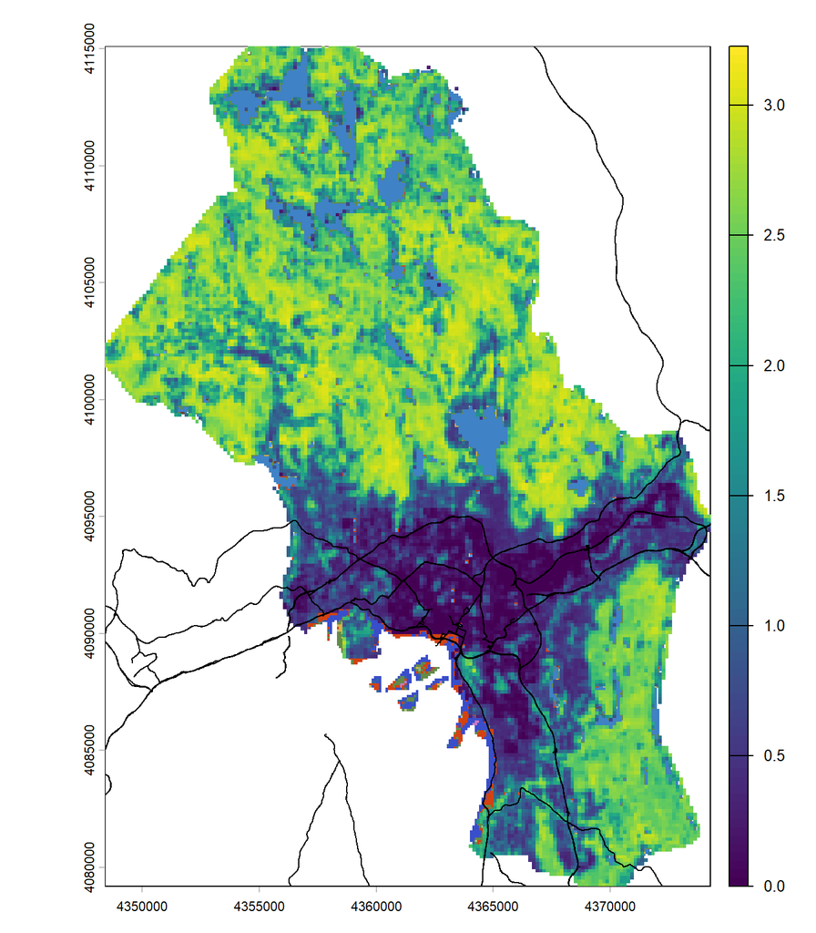

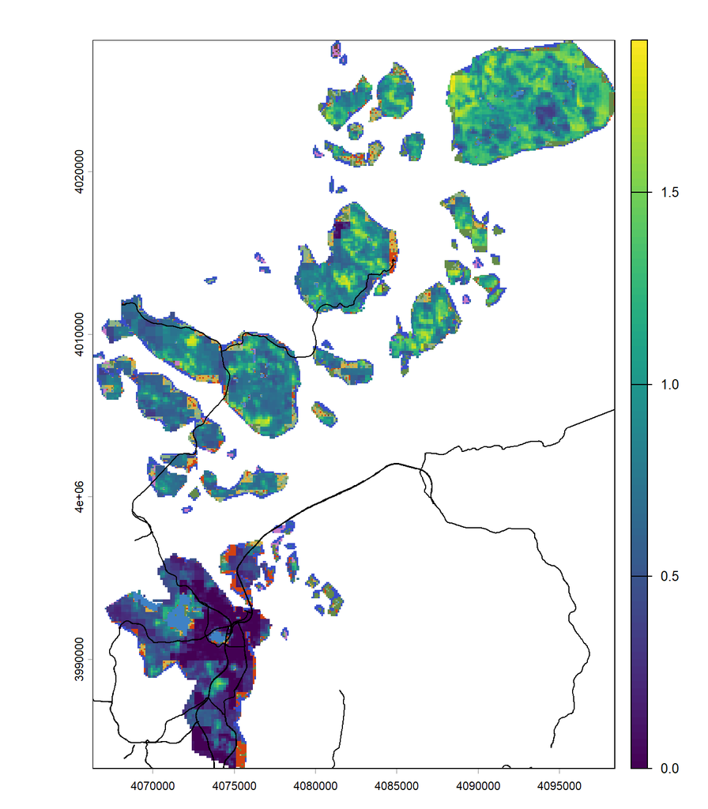

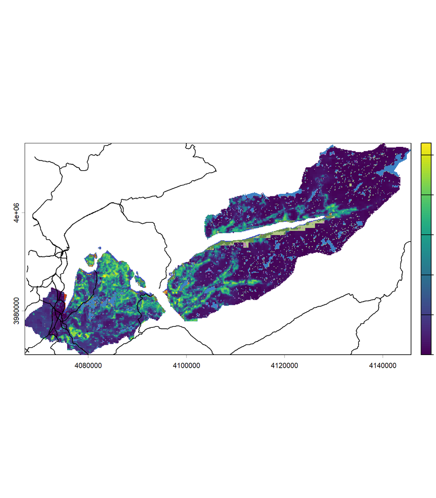

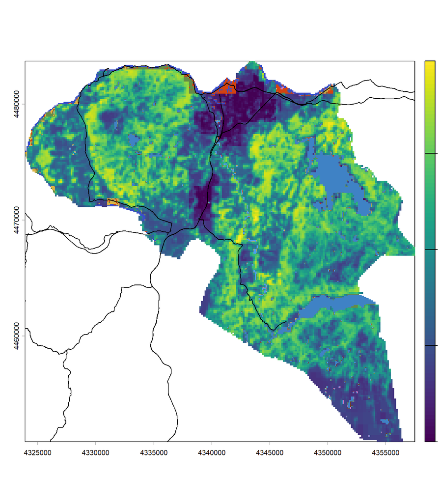

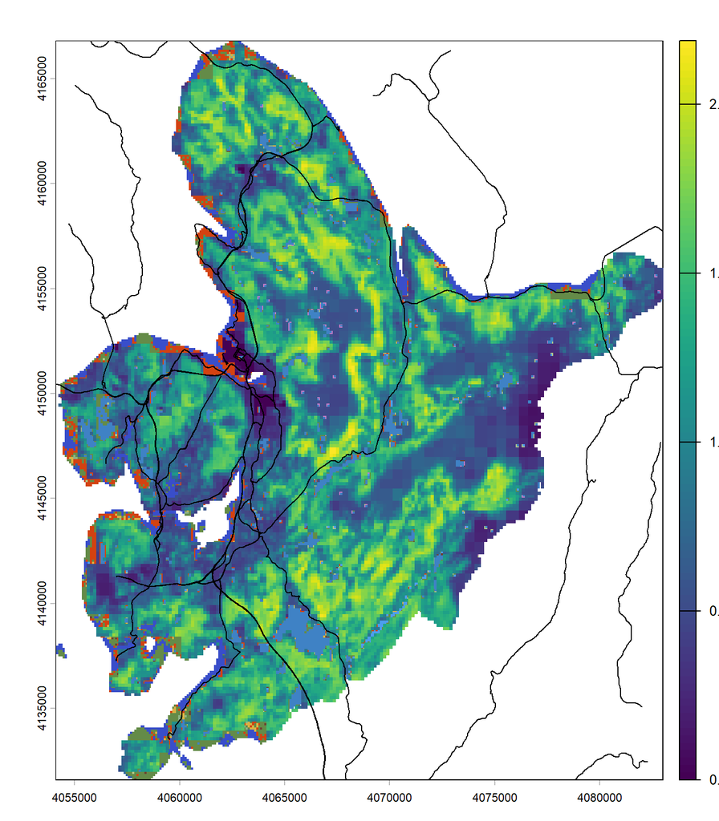

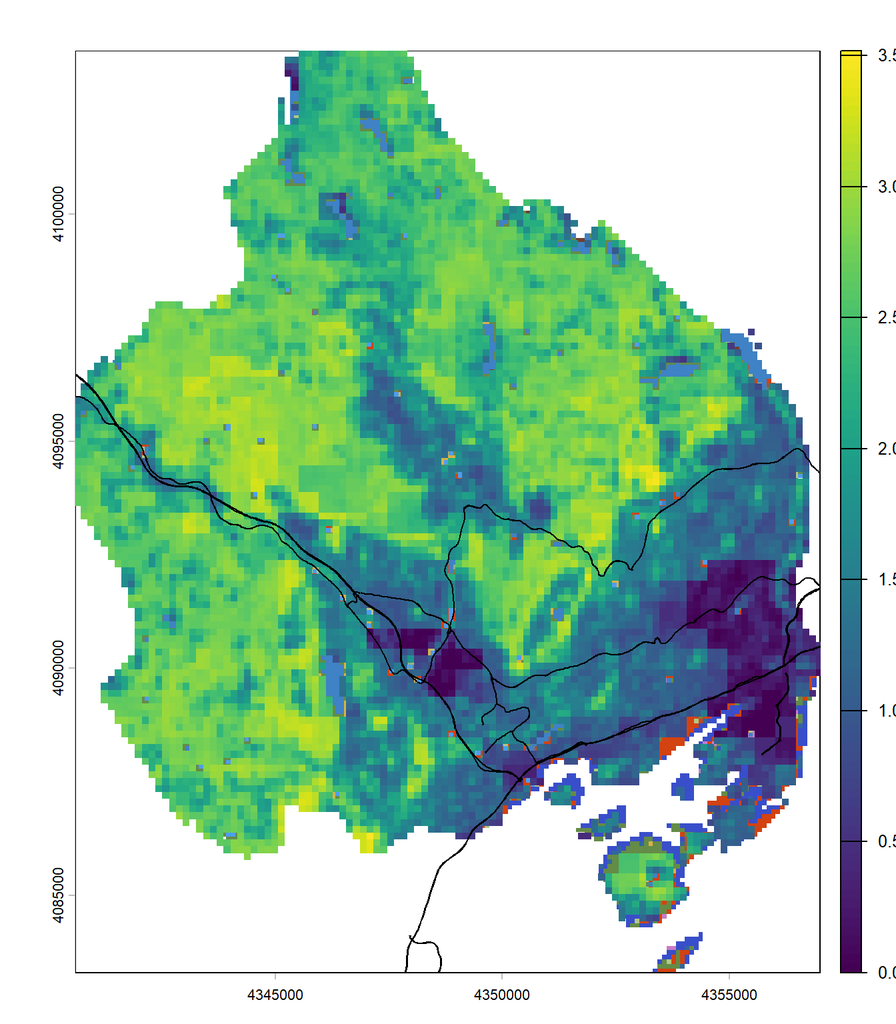

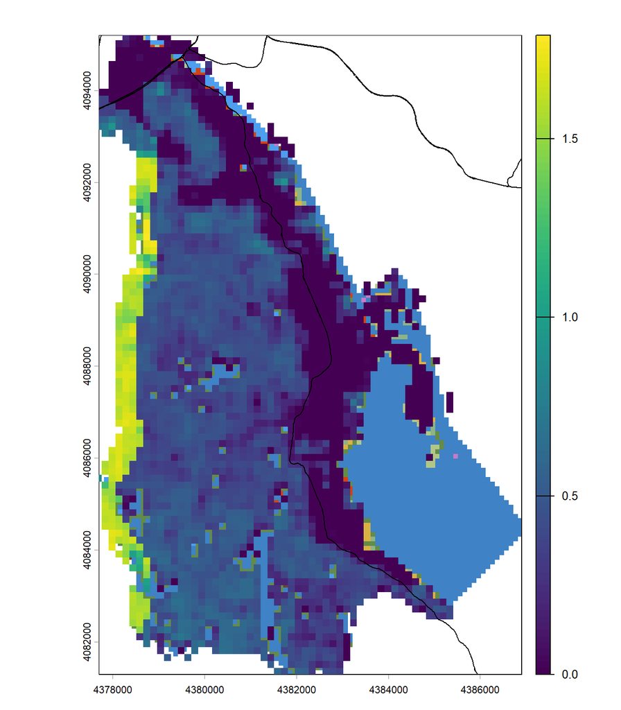

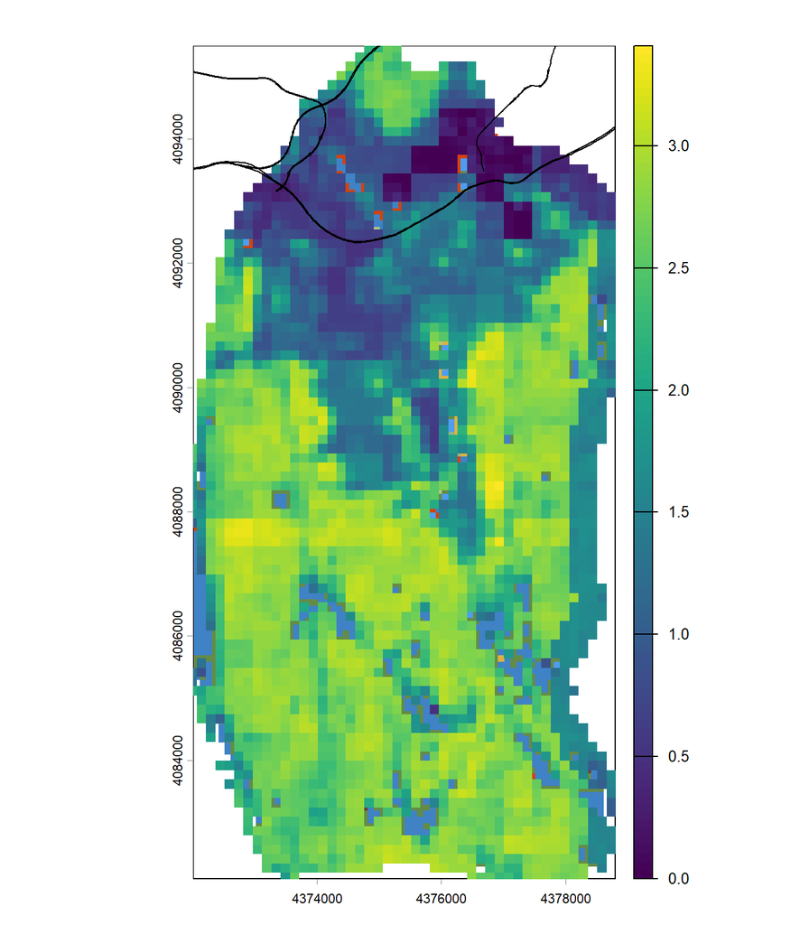

```r
j=2
for(i in 1:nrow(cityb_buf_l[[j]])){
   plot(crop(lcm,cityb_l[[j]][i,],mask=T),legend=F)
  plot(crop(cooling_stack_e[[j]], cityb_buf_l[[j]][i,],mask=T), main=paste(cityb_buf_l[[j]]$LAU_NAME[i],"cooling","month",mdr[j]),add=T,legend=T)
  plot(roads_list[[i]],add=T)
}
```

### 6.2.2 Strict urban version

```r
gc()
### We run this as a loop across months and cities. Following INCA's python implementation as close as possible
cooling_list_m <- vector("list", length(mdr))
for(j in 1:length(mdr)){
  # make a list for the city-wise cooling rasters
  cooling_list <- vector("list", nrow(cityb_buf_m_l[[j]]))
  for(i in 1:nrow(cityb_buf_m_l[[j]])){
    # get lcm
    tmp_lcm <- crop(lcm2,cityb_buf_m_l[[j]][i,],mask=T)
    tmp_lcm[tmp_lcm %in% c(810,910,1200)]<-NA # rivers, lakes, sea, are set to NA
    # get coefficients
    alpha1h_ <- firstdf_n$est_intercept[firstdf_n$month==mdr[j] & firstdf_n$city==cityb_buf_m_l[[j]]$LAU_NAME[i]]
    beta1h_ <- firstdf_n$est_tcd[firstdf_n$month==mdr[j] & firstdf_n$city==cityb_buf_m_l[[j]]$LAU_NAME[i]]
    gamma1h_ <- firstdf_n$est_evap[firstdf_n$month==mdr[j] & firstdf_n$city==cityb_buf_m$LAU_NAME[i]]
    # create simulated lst rasters
    lst_sim_green_ <- alpha1h_ + beta1h_*crop(tcdr_no,cityb_buf_m_l[[j]][i,],mask=T) + gamma1h_*crop(evapr_no,cityb_buf_m_l[[j]][i,],mask=T)
    lst_sim_gray_ <- alpha1h_ + 0*crop(tcdr_no,cityb_buf_m_l[[j]][i,],mask=T) + 0*crop(evapr_no,cityb_buf_m_l[[j]][i,],mask=T)
    # create simulated air temp rasters
    t_air_green_ <- alpha2h + beta2h*lst_sim_green_ + gamma2h*crop(lat_r,cityb_buf_m_l[[j]][i,],mask=T)
    t_air_gray_ <- alpha2h + beta2h*lst_sim_gray_ + gamma2h*crop(lat_r,cityb_buf_m_l[[j]][i,],mask=T)
    # cooling
    cooling_ <- t_air_gray_ - t_air_green_
    # as in INCA we force negative values to be zero
    cooling_[cooling_<0] <- 0
    # unlike in INCA (but as requested in the hanbook) we set cooling of water bodies to NA
    cooling_[is.na(tmp_lcm)] <- NA
    # save in stack
    cooling_list[[i]]<-cooling_
    # tidy up
    rm(alpha1h_,beta1h_,gamma1h_,lst_sim_gray_,lst_sim_green_,t_air_gray_,t_air_green_,cooling_,tmp_lcm)
  }
  # in this function now we put the cities together and impose the mean cooling for the overlapping boundaries
  cooling_list_m[[j]] <- do.call(terra::mosaic,c(cooling_list,fun=mean))
  # make sure extents align (when some urban areas are masked because of lack of heat, then it can happen that extent is smaller than usual)
  cooling_list_m[[j]] <- terra::extend(cooling_list_m[[j]],terra::ext(lcm))
  # save
  writeRaster(cooling_list_m[[j]],file.path(rfp,paste0("cooling_n_",j,".tif")),overwrite=T)
}
cooling_stack<-terra::rast(cooling_list_m)
names(cooling_stack)<-mdr
cooling_stack_n <- cooling_stack
rm(cooling_list_m,cooling_stack)
```